# Wu-PlatformInformationPriceTargeting-2025-SSRN.pdf

Converted from PDF `Wu-PlatformInformationPriceTargeting-2025-SSRN.pdf` · 66 pages · anchors: page `#pN`, block `#pN-bK`

Page 1

### Platform Information Design and Competitive Price Targeting

Ruiqi Wu, Yufeng Huang and Nan Li <sup>∗</sup>

May 23, 2025

#### **Abstract**

We study platform information design, in which a platform provides information about individual consumers, enabling sellers to set targeted prices. Because targetable information partitions the market and might intensify seller competition, what information should be provided remains an empirical question. We collect novel micro data from Steam, the dominant PC video game platform, and use granular consumer purchase and usage data to estimate their heterogeneous demand for video games. We then develop an equilibrium targeted pricing model to simulate counterfactual outcomes under all possible information designs. We demonstrate that the profit-maximizing information design—which distinguishes heterogeneous consumer types while accounting for the design’s equilibrium impact—yields substantially higher profits compared to demand-based heuristics that ignore the equilibrium impact.

**Keywords:** information design, competition, price targeting

∗Ruiqi Wu (ruiqiwu@udel.edu) is an Assistant Professor of Marketing at the Lerner College of Business and Economics, University of Delaware. Yufeng Huang (yufeng.huang@simon.rochester.edu) is an Associate Professor of Marketing at the Simon Business School, University of Rochester. Nan Li (nanli88@tongji.edu.cn) is an Assistant Professor of Marketing at the Advance Institute of Business, School of Economics and Management, Tongji University. Ruiqi Wu is deeply grateful to Paul Ellickson for his comments and support. We are also grateful for the comments and suggestions by Kristina Brecko, Hana Choi, Ron Goettler, Sam Goldberg, Avery Haviv, Joonhwi Joo, Tesary Lin, Mitch Lovett, Bowen Luo, Matt McGranaghan, Zach Nolan, Takeaki Sunada, and seminar and conference participants at Bentley University, Carnegie Mellon University, Chinese University of Hong Kong - Shenzhen, Fudan University, Lingnan University, Peking University, Renmin University of China, University of Delaware, University of Rochester, 2024 Quantitative Marketing and Economics Conference, 2023 Conference on Artificial Intelligence, Machine Learning and Business Analytics, 2023 International Industrial Organization Conference, and 2021 and 2023 Marketing Science Conferences. All errors are our own.

Page 2

### **1 Introduction**

A platform collects detailed data on individual consumer behavior across all its third-party sellers.

These comprehensive data allow the platform to pin down each consumer’s preference and price

sensitivity, putting it at a uniquely powerful position: The platform can decide what information

about each consumer to communicate to sellers and what to withhold from sellers, thereby influ-

encing whether and how prices and promotions are targeted to individual or groups of consumers.

In practice, a platform often designs of its infrastructure or rules to influence what information is

used in targeting (Bhargava et al., 2020). For example, advertising platforms such as Google and

Meta provide predefined interest labels about individual consumers, effectively dividing them into

segments. Online retail platforms such as Amazon and eBay are also developing lists of consumer

segments that sellers can target with price promotions or coupons.

Despite the increasing popularity of targeting, platforms do not have a clear understanding on

how they should optimally design targetable segments. From Shopify’s segmentation guidelines to

Google’s Topic API and Facebook’s behavioral taxonomy, practitioners often segment consumers

based on demographics and behavioral metrics, with the intent to group consumers with similar

preferences into the same segment. Whereas these segment designs reflect the established academic

insight that a *monopolist* can benefit from targeting consumer preferences (Rossi et al., 1996;

Smith et al., 2023; Dub´e and Misra, 2023), they rarely consider the implications on *competing*

sellers’ equilibrium strategies.

The equilibrium implications of price targeting are important because a segmentation scheme

partitions consumers into submarkets—each with its own local market structure—and consequently

affects competing sellers’ prices and equilibrium outcomes. These equilibrium implications, how-

ever, are nuanced. Theoretical and limited empirical works have shown that the impact of compet-

itive price targeting on profits and welfare are directionally ambiguous (Holmes, 1989; Corts, 1998;

Besanko et al., 2003; Dub´e et al., 2017). In addition, theoretical predictions depend on conditions

that are difficult to verify empirically, and do not easily generalize to realistic platform markets.

Moreover, beyond the binary case of whether or not firms can target, the extant literature is mostly

silent about how targetable segments should be designed.

In this paper, we characterize the platform’s design of targetable segments as an information

design problem, in which the platform-designed segments reveal information about individual con-

1

Page 3

sumer demand to sellers, who then use this information to set optimal targeted prices.<sup>1</sup> Using

detailed micro data from Steam, the dominant PC video game platform, our counterfactual simula-

tions demonstrate that incorporating equilibrium considerations is crucial for the optimal platform

information design.

We assemble a novel dataset containing individual-level panel data on consumer purchase and

usage behavior, and game characteristics derived from texts that describe the game’s content and

style. Using these data, we estimate a structural demand model that captures consumers’ joint deci-

sions of purchase and usage, measuring heterogeneous consumer preferences over multi-dimensional

product characteristics. In particular, the model allows consumers’ expected usage to affect their

purchase decisions, thereby uncovering consumer preferences using data on which games they pur-

chase and on how intensively they engage with these games. Our demand estimates identify eight

latent consumer types, who differ in their overall engagement with gaming, tastes for specific game

features, and sensitivities to prices. Importantly, assuming zero marginal costs, our estimates im-

ply equilibrium uniform prices that closely match the observed uniform prices on Steam, lending

credibility to these estimates as the basis of counterfactual equilibrium outcomes.

Next, we develop an equilibrium targeted pricing model to simulate alternative platform in-

formation design scenarios. We extend the standard uniform pricing equilibrium (Berry et al.,

1995)—where sellers are informed about the consumer type distribution but have no information

about individual consumer types—to a targeted pricing equilibrium where sellers also have some

information that allow them to infer each consumer’s type. When all sellers have the same informa-

tion about each consumer, the equilibrium is one where the platform effectively groups consumers

into segments, with sellers competing for each segment as a distinct submarket.<sup>2</sup> The model also

generalizes to the case where sellers hold different information about each consumer and thereby

compete in partially overlapping submarkets (see Appendix C).

Our results demonstrate that targeted pricing significantly improves total profits when im-

plemented with the optimal information design—one that maximizes the total profits among the

platform and all sellers. We arrive at this first conclusion by simulating all 4*,* 140 information

designs, each representing a distinct information set. We find that targeting based on full infor-

mation generates a 2.88% increase in total profits relative to uniform pricing, which is equivalent

1The term “information design” follows Bergemann and Morris (2019) in that the information designer (who is the platform) commits to the choice of the best information structure for a set of participants in the game (who are sellers that use this information for targeted pricing).

2In this case, one can interpret the platform’s information design either as provision of information (which is our primary interpretation) or as a rule that restricts what information price targeting can be based on.

2

Page 4

to approximately $124 million per year. However, targeting based on coarse consumer information

generates drastically different market outcomes depending on how the information set is designed.

For example, among all “Coarse 2” designs—allowing just two price segments—the platform can

achieve profit increases over uniform pricing that range from 1.74% to a mere 0.05%, suggesting

that optimal information design plays a critical role given the granularity of targetable information.

We proceed to demonstrate that equilibrium considerations are paramount in obtaining the op-

timal information design. We arrive at this second conclusion by simulating counterfactual designs

of targetable segments based on the grouping of consumer types with similar price elasticity pat-

terns, among other demand-based heuristics. We find that, holding fixed the level of granularity,

these heuristics consistently lead to much less effective targeting than the optimal information de-

sign. For example, with two targetable segments, elasticity-based heuristics yield an approximately

one percentage point lower profits compared to the optimal design, leaving $43 million in annual

profits on the table. This profit gap persists across alternative heuristics and remains robust to

different sources of consumer heterogeneity, demonstrating that demand-based heuristics, which

represent similarity in consumers’ price sensitivities or tastes, fail to approximate the platform’s

optimal design that also accounts for its impact on sellers’ equilibrium strategies.

Beyond the maximization of total profits across the platform and all sellers, we also demonstrate

that the optimal information design substantially improves consumer welfare, the platform’s profit,

and the balance of competition across large versus small sellers, suggesting that well-designed infor-

mation structures can simultaneously benefit a broad set of market participants in the ecosystem.

Our findings offer important managerial implications for platforms that provide consumer in-

formation to sellers. The prior literature emphasizes how a single seller can use advanced models

and rich datasets to uncover individual-level demand heterogeneity, enabling precise targeting of

distinct consumer types. In contrast, we demonstrate that in a marketplace with competing sellers,

the platform must also account for how its information design affects seller competition in equi-

librium. This equilibrium consideration is especially crucial when the platform intends to provide

only a limited number of consumer segments—a likely scenario given practical constraints such

as implementation or menu costs (Sheshinski and Weiss, 1977), privacy concerns (Goldfarb and

Tucker, 2019), and fairness considerations (Kahneman et al., 1986), all of which tend to favor the

provision of few coarsened consumer segments. To this end, we develop an empirical framework

that captures how the information available to competing sellers shapes equilibrium prices, profits,

and consumer surplus. Our framework is generalizable across platforms with diverse consumer

3

Page 5

compositions and objectives.

**Related Literature.** We extend the literature on competitive third-degree price discrimination

by addressing the information design problem faced by online platforms. Prior theoretical work has

shown that targeted pricing can either enhance or harm competing sellers’ profits, depending on the

structure of consumer preference heterogeneity (Thisse and Vives, 1988; Holmes, 1989; Shaffer and

Zhang, 1995; Corts, 1998; Chen and Iyer, 2002; Armstrong, 2006). However, the direction of profit

(and welfare) impacts relies on conditions that are not easy to verify empirically.<sup>3</sup> In addition,

existing theoretical findings are typically derived under restrictive assumptions—most notably,

markets with only two single-product sellers and limited forms of consumer heterogeneity—and

do not easily generalize to modern marketplaces characterized by richer consumer heterogeneity

and market structures. In the meantime, a small but growing empirical literature similarly focuses

on settings with two competing firms and limited consumer heterogeneity (Besanko et al., 2003;

Dub´e et al., 2017). Our contribution is twofold. First, we extend the empirical literature to

a more realistic platform setting involving numerous single- and multi-product sellers and multi-

dimensional consumer heterogeneity. Second, we introduce a framework that enables simulations of

counterfactual equilibrium outcomes beyond the boundary cases of full-information and no targeting

to systematically evaluate the continuum of intermediate information designs—where platforms

enable targeting based on partial information about consumers.<sup>4</sup>

Our paper also contributes to the growing literature on platform information design, particularly

through the design of infrastructure and rules (Bhargava et al., 2020). Most existing studies on

information design focus on providing information to consumers—about sellers or products—often

through mechanisms such as reputation systems, warranties, or quality guarantees (Hui et al.,

2021; Vatter, 2022; Hopenhayn and Saeedi, 2022; Hopenhayn et al., 2022; Hui et al., 2023). In

contrast, we examine the platform’s role in providing information to sellers, specifically shaping

sellers’ beliefs about individual consumers through the design of coarse segmentation. Our focus on

competitive price targeting distinguishes this work from the literature on monetizing data through

targeted advertising (Bergemann and Bonatti, 2024), and our conceptualization of information

design differs from studies on the market for data transactions between sellers and intermediaries

3For example, Corts (1998)’s key condition is whether two competing firms’ rank orders between a “strong” consumer type and a “weak” consumer type coincide, a condition defined on firms’ best response functions between targeted-pricing and uniform-pricing equilibrium.

4While not being their main point, Dub´e et al. (2017) also empirically examine how targeting based on behavioral types or geographic locations affects equilibrium outcomes, answering a question related to ours—which consumer information should sellers target.

4

Page 6

(Pancras and Sudhir, 2007; Bergemann and Bonatti, 2015).

Broadly, our empirical study also presents new insights on the pricing of digital content, espe-

cially digital video games (Rao, 2015; Sunada, 2018; Brecko, 2023).

The rest of the paper is organized as follows. Section 2 conceptualizes the platform information

design problem. Section 3 introduces the context and data. Section 4 sets up the demand and

equilibrium pricing model. Section 5 presents estimation results. Section 6 discusses the value of

information design through counterfactual simulations. Section 7 concludes the paper.

### **2 Conceptual model: Information and competitive price-targeting**

**Setup.** We present a simple conceptual model to illustrate the importance of accounting for seller

competition in a platform’s information design. Assume that two single-product sellers, *A* and *B*,

compete for each consumer, *i*. The consumer’s utility for product *j ∈{A, B}* depends on her taste

for the product, *βij*, a price coefficient normalized to *−*1, and a type-1 extreme value utility shock:

*Uij* = *βij −*Price*ij* + *ϵij.* (1)

**equation / math rendering (image)**

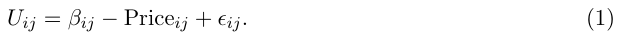

NOTE: contains mathematical notation; text above is the PDF text layer and symbols may be mis-extracted. Image shows the original.

The consumer can also choose not to purchase, which yields *Ui*0 = *ϵi*0. Without loss of generality,

we normalize both sellers’ marginal costs to zero.

Consumer taste for each product, *βij*, is heterogeneous. Assume *βij* can take either a high value

(*H*) or a low value (*L*), resulting in four types of consumers, labeled 1*,* 2*,* 3*,* 4, who are characterized

by preferences (*βiA, βiB*) = (*L, L*), (*L, H*), (*H, L*), and (*H, H*), respectively. We set *H* = 2 and

**equation / math rendering (image)**

NOTE: contains mathematical notation; text above is the PDF text layer and symbols may be mis-extracted. Image shows the original.

*L* = 1, and assume each type constitutes 25% of the market. We also assume that sellers know

the value of *H* and *L* and the proportion of each consumer type in the market, but not individual

consumer *i*’s type. Therefore, without additional information, sellers set uniform equilibrium prices

for all consumers based on the distribution of consumer types.

**Information design.** We assume the platform knows each *individual* consumer’s type. Because

the platform controls the information environment, it can decide what individual consumer infor-

mation to communicate to sellers, thus allowing them to target groups of consumers using the

information. Formally, we characterize a specific information design as a partition of the set of

consumer types, *{*1*,* 2*,* 3*,* 4*}*, where each partition corresponds to a grouping of types into coarsened

segments.

5

Page 7

Given the platform’s information design, sellers update their beliefs about each consumer’s type

based on the segment to which the consumer belongs, and set equilibrium prices accordingly. At one

extreme, the platform can disclose full information about consumer types, designing an information

set *{{*1*}, {*2*}, {*3*}, {*4*}}*. In this case, sellers know and can set equilibrium targeted prices for each

consumer type. At the other extreme, the platform can disclose no information about individual

types, designing an information set *{{*1*,* 2*,* 3*,* 4*}}*. In this case, sellers must rely solely on their prior

beliefs about the consumer type distribution and set uniform equilibrium prices.

Alternatively, the platform can provide a coarsened information set which reveals certain as-

pect(s) of consumer heterogeneity and conceals other aspects. For example, the platform can

provide information on consumers’ taste for product *B* while withholding information about con-

sumer taste for product *A*, designing the information set *{{*1*,* 3*}, {*2*,* 4*}}*. In practice, this means

grouping types (*L, L*) and (*H, L*) into coarse segment *I*, and types (*L, H*) and (*H, H*) into coarse

segment *II*, and informing sellers of each segment’s composition. Rational sellers will then infer

that consumers in segment *I* are equally likely to be type 1 or type 3, with a similar inference for

segment *II*. Sellers set equilibrium prices for each segment accordingly, following the first-order

conditions detailed in Section 4.2.

Table 2.1: Seller A’s Equilibrium Prices and Profits under Alternative Information Designs

|  | Uniform |  | Full -info |  | Optimal -Coarsened |  |
| --- | --- | --- | --- | --- | --- | --- |
| Type | Preference Price | Profit | Price | Profit | Price | Profit |
| 1 | (LL) 159 , . | 042 . | 140 . | 040 . | 140 . | 040 . |
| 2 | (LH) 159 , . | 029 . | 132 . | 032 . | 164 . | 029 . |
| 3 | (HL) 159 , . | 078 . | 175 . | 075 . | 164 . | 079 . |
| 4 | (HH) 159 , . | 060 . | 160 . | 060 . | 164 . | 061 . |
|  | Total($) | 208 . |  | 206 . |  | 210 . |
|  | Change | — |  | 10% - . |  | 05% . |

NOTE: table converted from PDF layout to HTML text; cell boundaries are reconstructed. See PDF if exact alignment matters.

Note: This table presents seller *A*’s price and profit for each consumer type between the three information designs. By symmetry, seller *B*’s price and profit are the mirror image (e.g., *B*’s price for type 2 is $1.75, the same as A’s price for type 3). Across the information designs, “Uniform” refers to no targeting, “Full-info” refers to targeting each type, and “Coarsened” refers to when the platform provides the *optimal* coarsened information *{{*1*}, {*2*,* 3*,* 4*}}* that maximizes the sellers’ and the platform’s profits, allowing sellers to target two segments in total.

**Equilibrium prices and profits.** We solve for the equilibrium outcomes under all information

designs in this conceptual example and report the resulting prices and profits for three information

designs in Table 2.1. The first column presents the scenario in which the platform provides no

6

Page 8

information about individual types (information set *{{*1*,* 2*,* 3*,* 4*}}*), resulting in sellers setting uni-

form prices. The equilibrium price is $1*.*59 for all consumers, which falls between the dollar-valued

intercepts $2 and $1 for the two types. The second column presents the opposite scenario where

the platform provides full information, *{{*1*}, {*2*}, {*3*}, {*4*}}*. In this case, sellers set prices that

target each consumer type. The way targeted prices differ from uniform prices reflects consumer

heterogeneity. Specifically, both sellers lower the price to $1.40 for type 1 consumers, who have low

preferences for both products, and raise it to $1.60 for type 4 consumers, who have high preferences

for both products. In addition, seller *A* reduces the price for type 2 consumers, who prefer the

competitor’s product, and raises the price for type 3, who prefer the focal product. Seller *B*’s prices

are symmetric to *A*’s.

One might expect targeting to increase profits. However, in this case, full-information targeted

prices in fact reduces profits compared to uniform prices. As shown in Table 2.1, a decomposition

of equilibrium profits by consumer type reveals an interesting pattern: with full information, seller

*A*’s profits from consumer types 1 and 3—those with lower preferences for seller *B*—decline by

about 4%. The profit loss arises because seller *B*, who targets these consumer types with lower

prices ($1.40 for type 1 and $1.32 for type 3), effectively lowers seller *A*’s residual demand. By

symmetry, the same happens to seller *B* for types 1 and 2. In other words, although each seller sets

type-specific prices to maximize its own profit from each consumer type, the competitor’s targeting

can lower residual demand, intensify competition, and lead to lower total equilibrium profits. This

finding under competing sellers sharply contrasts with the case with a monopoly seller, where price

targeting never hurts profits (Smith et al., 2023; Dub´e and Misra, 2023).

**Profit-maximizing coarsened information design.** We further examine the 13 intermediate

cases where the platform limits the consumer information shared with sellers and thus allows only

partial targeting. We refer to these cases as *coarsened* information designs and present their profit

increase relative to the no-information scenario in Figure 2.1. The design that maximizes total

seller profit is *{{*1*}, {*2*,* 3*,* 4*}}*, which increases profits by 0.5% relative to the uniform equilibrium

(1.5% relative to the full-information case). This optimal design separates consumers based on

whether they exhibit a low probability of purchasing either product but pools all other consumers.

As shown in Table 2.1, under full information, seller *A* significantly loses profit in its stronghold,

type 3, when seller *B* can poach them with a lower price. By contrast, under optimal coarsened

design, seller *B* sets a less aggressive price, catering to the coarsened segment *{*2*,* 3*,* 4*}*, leading

7

Page 9

to higher residual demand and profits for the seller *A*. Along the same line, two other coarsened

designs that pool consumers with distinct tastes also result in profit gains. Conversely, designs that

separate these two consumer types into distinct segments significantly reduce sellers’ profits, with

the least profitable design reducing total profit by 1.5%.

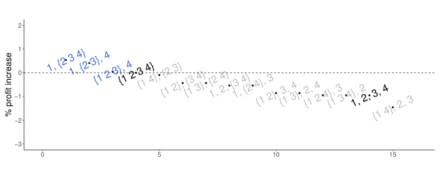

NOTE: figure/graphic rendered as an image from the PDF; its content is not machine-readable text. Caption (if any) follows as the next block.

**text found inside the figure**

1, {2 3 4} 1, {2 3}, 4

{1 2 3}, 4

{1 2 3 4}

{1 4}, {2 3}

{1 2}, {3 4}

{1 3}, {2 4}

1, 2, {3 4} 1, {2 4}, 3

{1 2}, 3, 4

{1 3}, 2, 4

{1 2 4}, 3

{1 3 4}, 2

1, 2, 3, 4

{1 4}, 2, 3

−3

−2

−1

0

1

2

0 5 10 15

% profit increase

Figure 2.1: Information and total profits in equilibirum

Note: we present profit as the % increases relative to the uniform pricing equilibrium. For readability, we suppress the outer braces and braces for singleton sets. For example, we denote information set *{{*1*}, {*2*,* 3*,* 4*}}* by 1*, {*2*,* 3*,* 4*}*.

**Discussions.** Our conceptual and structural model interprets the provision of segment labels as a

source of information, which allows sellers—otherwise with no information about each consumer—

to infer the consumer’s type and set targeted prices. Alternatively, when the same information

is imposed on all sellers, one can interpret the segment labels as a restriction on the aspects of

consumer information that sellers are allowed to target. As a result, sellers set equilibrium prices for

each segmented market, similar to zone pricing in physical retail (Adams and Williams, 2019). This

alternative interpretation is isomorphic in our structural analysis and leads to the same findings.

Moreover, although we abstract away from the specifics of implementation, our proposed in-

formation design framework aligns well with current platform practices and can be supported by

existing technologies. For instance, platforms like Google may assign consumer labels to indicate

individual preferences, while platforms such as Amazon and eBay allow sellers to target pre-defined

consumer groups through their seller interfaces (see Appendix Figure A.1). What may differ from

existing practices is how to define targetable segments. Here, and in our empirical analysis, we

demonstrate that optimal information design should account for its equilibrium impacts.

8

Page 10

### **3 Context, Data, and Descriptive Statistics**

#### **3.1 Context: Steam**

Steam, owned by Valve Software, is the world’s largest digital marketplace for PC video games. It is

estimated to hold 75% of the market share, offering over 30,000 games, software titles, and add-ons

(Zuckerman, 2020). Consistent with this estimate, Google Trends data show that Steam consis-

tently dominates consumer search interests, indicating limited competition from other platforms

(see Appendix B).

Like other online marketplaces, Steam allows third-party sellers to list games and set their own

prices. These sellers range from major publishers like Ubisoft and Sega to small indie studios with

only a few titles. Consumers can access the platform for free but must purchase games to play them.

Once purchased, a game is added to the user’s library and remains accessible indefinitely. Steam

processes all payment and charges a 30% commission fee from it. Since 2017, this commission has

been Steam’s primary revenue source, with third-party titles accounting for 98% of total transaction

value and Valve’s own games comprising just 2% during our sample period.

We highlight three industry details of Steam that help us study the information design question.

First, because Steam processes all transactions and hosts all gaming sessions, it tracks the entire

game purchases and usage history for each consumer. These micro data contain crucial information

for us to estimate and understand consumer heterogeneity, a critical prerequisite for analyzing the

profitability of price targeting.

Second, Steam does not allow targeted prices or targeted coupons during the sample period.<sup>5</sup>

The absence of targeting allows us to observe the prices facing all consumers, thereby alleviating

concerns about unobserved discounts that may arise due to targeting.

Third, several institutional features suggest that sellers primarily make pricing decisions to

maximize game sales revenue. In particular, Steam does not sell advertising slots, so sellers do not

make advertising decisions on Steam.<sup>6</sup> Additionally, although Steam recommends games based on

individual consumers’ interests, it has explicitly committed to not using prices in the recommen-

5This price uniformity is upheld with rare exceptions. Only one single anecdote exists where a large seller requested Steam to distribute targeted coupons to specific previous buyers, which is outside our sample period. Moreover, there is little anecdotal evidence of sellers circumventing the system by emailing consumers targeted coupons, primarily because Valve does not share consumers’ email address with the publishers. See https://store.steampowered.com/privacy agreement/ for more details.

6Steam’s detailed policy regarding sellers’ advertising and other marketing activities is publicly stated at https:// partner.steamgames.com/doc/marketing/tools.

9

Page 11

dation system.<sup>7</sup> This fact allows us to abstract away from modeling the effect of prices on Steam’s

recommendation and thus consumers’ consideration sets. Moreover, upfront sales revenue remains

the dominant source of income for sellers: only 3% of games offer in-game purchases, and in-game

advertising is discouraged and has since been banned.<sup>8</sup> Further, because Steam distributes digital

game copies via its own servers, sellers face negligible marginal costs (similar to other digital goods,

Rao, 2015). Given these factors, it is plausible to assume that sellers set prices to maximize the

revenue from game sales, thereby allowing for a tractable model to characterize sellers’ equilibrium

pricing behavior.

#### **3.2 Data**

**Data collection.** We collect consumer panel data directly from Steam’s store website, commu-

nity API, and storefront API. We start by randomly sampling one million existing Steam users

in December 2016, with approximately 810,000 (81%) having accessible public accounts.<sup>9</sup> Subse-

quently, we narrow down the sample to 131,539 users who owned at least one game and logged in

at least once in December 2016. For this sample, from February 5, 2017, to December 6, 2017, we

track the games in each user’s library and their cumulative playing time on a daily basis. We back

out the purchase history by recording the day a user adds each game to her library, and we compute

daily usage time at the minute level by taking the first difference on the cumulative time.<sup>10</sup> We

retain a final sample of 34,548 active users who had positive spending and usage throughout the

sample period and remained on Steam until at least November 2017.

Next, we collect daily price data for the 17,686 games available during the sample period.

We observe both regular prices and the final prices post-discounts. Additionally, we collect the

detailed characteristics of 4,581 popular games, such as developers, publishers, game descriptions,

and user-generated tags, from a third-party data aggregator.<sup>11</sup>

7See https://steamcommunity.com/games/593110/announcements/detail/1612767708821405787 for details. 8On the current search page (accessed in October 2023), we count the number of games with user-generated tags “free to play” and “in-app purchases.” We find that 6.1% of games (5,536/87,103) have the tag “free to play,” and 2.7% (2,380/87,103) have the tag “in-app purchases.” We verify that the tag “free to play” is accurate because the number of “free to play” games is similar to the number of games that currently have a price of zero. Furthermore, Steam formally banned in-game advertising in February 2025. See Steamworks Advertising Guidelines for more details.

9All Steam account profiles were public by default during that time. Users opting into the private mode or not registering on the Steam community would appear as missing or inaccessible accounts.

11The data from the third-party aggregator focuses on popular games on Steam as of 2020. Though the data only cover a subsample of games, it includes the most prominent games during our sample period, accounting for 99% of

10

Page 12

**Measuring product features by meta-tags.** A crucial step in our analysis is to characterize

product differentiation. Whereas each game possesses unique content and potentially appeals to a

particular consumer type, it is computationally infeasible to uncover consumer tastes at the product

level, especially with a large number of products.<sup>12</sup> To address this challenge, we characterize each

game as a combination of key features that encapsulate its distinct content.

We derive these features from user-generated tags, which reflect each game’s content in detail.

For example, the popular first-person shooter (FPS) game, “Counter Strike: Global Offensive,”

has tags “FPS,” “Shooter,” “Multiplayer,” “Competitive,” “Team-based,” “e-sports,” “Tactical,”

and so on. These tags provide finer-grained information than genres and capture more nuanced

differences across games that are relevant to users’ purchase decisions.<sup>13</sup> However, given the 311

unique tags present across all games, estimating heterogeneous consumer preferences in such high

dimensions is challenging. Therefore, we group tags with similar semantic meanings or describe

similar contexts together to reflect the primary elements consumers seek in game content.

We use Global Vectors (GloVe) to capture the meaning of tags (Pennington et al., 2014).

First, we obtain 200-dimensional word embeddings for each tag from a pre-trained GloVe model

based on Twitter data.<sup>14</sup> Second, we cluster these word embeddings using a hierarchical clustering

algorithm and manually correct misclassified tags. We then assign a “meta-tag” to each word

cluster, summarizing the common feature described by the words. In total, we define nine meta-

tags and present them in Appendix Table B.1. Each meta-tag is a binary variable indicating

whether any original game tag belongs to the corresponding cluster. Note that these meta-tags

are not mutually exclusive—a game can possess more than one meta-tag if it encompasses multiple

features. On average, a game has 18 original tags and 2.6 meta-tags. In Section 4, we capture

heterogeneous tastes for games using these defined meta-tags.

#### **3.3 Descriptive statistics**

We present descriptive statistics that motivate our subsequent analyses. First, we demonstrate

that the market structure on Steam is complex, where a large number of sellers each offering one or

the usage time and 86% of the expenditure share. Games not covered are either too niche or have exited the market by 2020. For the game sample used in structural estimation, we collect the missing information for games that are not covered. We only have to fill in information for two out of the 171 focal games.

12With *J* products and *R* consumer types, one needs to estimate *J ×R* parameters for product tastes, which grows quickly with *J* when *R* is high.

13See https://www.youtube.com/watch?v=Jsc7 XjFZ6U&t=319s and https://steamcommunity.com/discussions/ forum/1/1480982971157417258/ for details.

14See *https://nlp.stanford.edu/projects/glove/* for details.

11

Page 13

multiple differentiated products. Second, we document substantial consumer heterogeneity across

multiple dimensions—such as purchase frequency, game-play intensity, and preferences for game

features. Third, we examine current pricing patterns across games, highlighting the key source of

identifying variation for demand.

(a) Number of games per seller (seller size)

1 2−5 6−10 11−20 >20 Games per seller

Number of sellers

0 200 400 600 800 1200

1321

417

60 14 31

(b) Revenue share by seller sizes

1 2−5 6−10 11−20 >20 Games per seller

Revenue share (%)

0 10 20 30 40 50

20.9 17.4

11.2

2.4

48.1

Figure 3.1: Market structure

**Market structure.** We demonstrate that Steam’s market structure differs significantly from

canonical theory models of targeted pricing, which typically feature two firms that each offer a

single product (Holmes, 1989; Corts, 1998). Figure 3.1 presents the distribution of seller sizes—in

terms of their number of games—and revenue shares. We note that Steam is occupied by a few large,

multi-product sellers and a long tail of small, single-product sellers. The 31 largest sellers, each

with more than 20 games, collectively take 48% of the revenue. In contrast, 1,321 single-product

sellers collectively contribute 21% of the revenue.

Moreover, because the large sellers often house multiple development teams that work concur-

rently on distinct projects, they not only offer a greater number of games but also span a broader

range of product features.<sup>15</sup> As shown in Figure 3.2, most of the largest 31 sellers have some games

that cover each of the product attributes, while smaller sellers are more dispersed in the game

features developed. The presence of multi-product sellers and product differentiation within each

seller brings forth a more complicated setting, one where existing theories do not apply. Thus,

15As an example, as of May 2021, Ubisoft employs over 20,000 individuals across more than 45 studios.

12

Page 14

platform information design is an empirical question.<sup>16</sup>

(a) % of *games* with meta-tags: sellers of different size categories

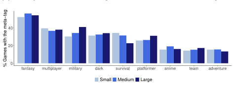

NOTE: figure/graphic rendered as an image from the PDF; its content is not machine-readable text. Caption (if any) follows as the next block.

**text found inside the figure**

0

20

40

fantasy multiplayer military dark survival platformer anime team adventure

% Games with the meta−tag

Small Medium Large

(b) % of *sellers* with meta-tags: sellers of different size categories

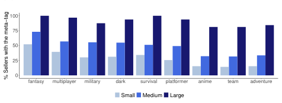

NOTE: figure/graphic rendered as an image from the PDF; its content is not machine-readable text. Caption (if any) follows as the next block.

**text found inside the figure**

0

25

50

75

100

fantasy multiplayer military dark survival platformer anime team adventure

% Sellers with the meta−tag

Small Medium Large

Figure 3.2: Larger sellers cover a wider set of features

Note: We categorize sellers with one game as “small,” those with 2 to 20 games as “medium,” and those with more than 20 games as “large.” A seller has a certain meta-tag when at least one game of this seller has the meta-tag.

**Consumer heterogeneity.** We explore the behavior of active Steam users using the individual

panel data and present the summary statistics in Table 3.1. Notably, consumers are highly engaged

with Steam—over the ten-month sample period, a user logs into the platform for 44.8% days (about

three times a week), spends $157, purchases 16 games, plays 17 games, and spends 1.5 hours playing

general preferences for games with certain meta-tags, such as multiplayer, military, and fantasy,

over other meta-tags, such as team, adventure, or anime.

Moreover, the interquartile ranges in Table 3.1 reveal considerable heterogeneity among users

in the three behavioral aspects—overall engagement, price sensitivity, and tastes in-game features.

The overall engagement differs sharply across users. In the bottom quartile, consumers log in less

than twice a week, spends $32 dollars, plays for 0.6 hour daily, purchases 4 games, and plays only

16Beyond the number of sellers and the presence of multi-product sellers, another departure from existing theory is the fact that the platform directly sells its own games while charging commission fees on other games. Nevertheless, as discussed in Section 3.1, platform-owned games take 2% of total sales revenue in the market, and its profits primarily come from third-party games.

13

Page 15

Table 3.1: Heterogeneity across Active Steam Users

| Statistic | Mean | St Dev . . | Pctl(25) | Median | Pctl(75) |
| --- | --- | --- | --- | --- | --- |
| % days logged in spending ($) Ngamespurchased . . Ngamesplayed . . daily hours | 448 . 1571 . 155 . 165 . 15 . | 235 . 2571 . 257 . 166 . 13 . | 258 . 320 . 4 6 06 . | 430 . 800 . 9 12 12 . | 627 . 1824 . 18 21 21 . |
| % regular price % on discount % for free | 411 . 291 . 298 . | 275 . 264 . 241 . | 211 . 38 . 93 . | 371 . 250 . 263 . | 556 . 464 . 500 . |
| % multiplayer % military % survival % team % fantasy % platformer % dark % adventure % anime | 551 . 473 . 359 . 290 . 477 . 341 . 393 . 127 . 103 . | 267 . 267 . 255 . 253 . 261 . 245 . 247 . 163 . 140 . | 370 . 297 . 189 . 114 . 333 . 182 . 238 . 00 . 00 . | 545 . 450 . 333 . 250 . 500 . 333 . 393 . 91 . 62 . | 727 . 625 . 500 . 400 . 649 . 500 . 519 . 200 . 162 . |

NOTE: table converted from PDF layout to HTML text; cell boundaries are reconstructed. See PDF if exact alignment matters.

Note: the table summarizes the distribution of three sets of behavioral statistics across the 34,548 active Steam users. The first set describes how engaged a user is, which includes the fraction of log-in days (when a user either purchases or plays something), the dollar amount spent, the number of games purchased and played, and the average playing hours per day. The second set presents the fraction of game purchases at regular prices, discounts, and when games are free. The third set shows the fraction of game purchases with certain meta tags.

6 games during the sample period. In contrast, users in the top quartile resemble heavy users,

as they log in more frequently, spend more money and time, and purchase and play a larger set

of games. In addition, price sensitivities and horizontal preferences across game features are also

heterogeneous, as evidenced by consumers’ purchases on games on discount and games with various

meta-tags. For example, in the bottom quartile, only 21% of purchases are under the regular price;

at the top quartile, this ratio rises to 56%, suggesting that some consumers are less price-sensitive

than others. All of the systematic consumer behavioral differences signify substantial consumer

heterogeneity, emphasizing the potential scope for price targeting.

**Current pricing.** Our primary source of price variation comes from the temporal price changes

within each game. On Steam, sellers adjust prices by altering regular prices or setting temporary

discounts.<sup>17</sup> For each game, we analyze how regular prices and final prices (i.e., effective prices

after discounts) change over time and present the pricing patterns across games in Table 3.2.

We highlight two noteworthy observations. First, regular prices for most games rarely change.

This observation differs from the console video game market, where regular prices tend to decline as

17See https://partner.steamgames.com/doc/marketing/discounts for Steam’s rules on discounts’ frequency, duration, and depth.

14

Page 16

Table 3.2: Pricing pattern across games

| Statistic | N | Mean | Min | Pctl(25) | Median | Pctl(75) | Max |
| --- | --- | --- | --- | --- | --- | --- | --- |
| average regular price ($) | 17686 , | 87 . | 00 . | 30 . | 61 . | 100 . | 1000 . |
| SD( regular price) ($) | 17686 , | 03 . | 00 . | 00 . | 00 . | 00 . | 1038 . |
| SD(final price) | 17686 , | 14 . | 00 . | 02 . | 09 . | 20 . | 463 . |
| % days on discount | 17686 , | 110 . | 00 . | 43 . | 92 . | 155 . | 1000 . |
| average $ off on discount | 14005 , | 49 . | 01 . | 16 . | 36 . | 66 . | 789 . |
| average % off on discount | 14005 , | 503 . | 42 . | 333 . | 501 . | 701 . | 1000 . |
| % during sales event days | 14005 , | 323 . | 00 . | 00 . | 317 . | 500 . | 1000 . |

NOTE: table converted from PDF layout to HTML text; cell boundaries are reconstructed. See PDF if exact alignment matters.

Note: For each game, we calculate four statistics to describe its cross-time price variation: standard deviation of the regular price, standard deviation of the final price, number of days on discount, and the average percentage off when on discount. We present the distribution of these four statistics across games in this table.

used copies flood the market (Ishihara and Ching, 2019) or where sellers engage in price skimming

(Nair, 2007). Second, final prices fluctuate more, primarily driven by occasional steep discounts.

During our sample period, on average, a game is on discount 11% of the time, with an average

discount depth of 50% off the regular price. About 32% of the discounts coincide with Steam’s

platform-wide sales event, and the rest of the discounts occur outside the sales event window

throughout the year. Appendix Figure B.5 presents the pricing pattern of a game as a visual

representation.

We leverage sharp price discounts to identify price sensitivities.<sup>18</sup> By combining the price panel

with the consumer panel of purchases, we identify consumers’ heterogeneous price sensitivities from

how individual demand co-move with prices within short time windows. We present further details

on pricing patterns and discussions about the identification in Appendix B.4.

### **4 Structural Model**

#### **4.1 Demand: consumer purchase and usage decisions**

**Overview.** We model consumers’ joint purchase and usage behavior using a two-stage framework.

Similar to Crawford and Yurukoglu (2012), our model links purchase decisions to expected usage by

assuming consumers are willing to pay more for games that they anticipate using more frequently.

18We abstract away from price variations across geographic regions (e.g., U.S. or Europe), as we solely observe price series in U.S. stores. Nevertheless, we collect cross-region prices for all games included for structural estimation. The timing and depth of discounts are highly aligned across geographic regions, with a median cross-region weekly price correlation of 0*.*90, alleviating concern about the impact of cross-region price differences on our estimates. We also abstract away from bundling, as it requires modeling consumer purchases over a bundle of products and increases the computational burden. An examination of available bundles during our estimation period revealed that this practice was not prevalent among games in our estimation sample.

15

Page 17

In the data, purchases are less frequent than usage due to the durable nature of video games. As

such, jointly modeling the two decisions enables us to leverage both decisions to capture consumer

heterogeneity.

We illustrate the timing of a consumer’s two-stage decision in Figure 4.1. The consumer starts

a *week* with a set of games she already owns, which we refer to as her “library.” She faces two

purchase occasions, each of which allows her to purchase a game from the set of available (but not

yet purchased) games and expand her library. Subsequently, on each *day* of the week, the consumer

faces two usage occasions, each of which she can decide which game in her library to play and for

how long. Figure 4.1 shows an example: with Games 1 and 2 in her library at the beginning of the

week, the consumer considers buying Games 3, 4, both, or neither. If she purchases Game 3, she

will decide how to allocate time among Games 1, 2, and 3 or other activities every day of the week.

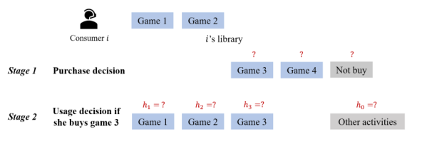

NOTE: figure/graphic rendered as an image from the PDF; its content is not machine-readable text. Caption (if any) follows as the next block.

Figure 4.1: An example of consumer’s purchase and usage decisions

Note: This figure describes the decision process of consumer *i* by an example. In the purchase stage, *i* chooses among games she does not own, or she does not buy anything. If *i* purchases a game, such as game 3, she will add it to her library. In the usage stage, she allocates time across games in her library and other activities.

**Usage stage.** We now characterize consumer decisions, starting with usage and then moving

backwards to purchase. Let *i* be a consumer, *j* be a game, *t* be a usage occasion (there are two

independent usage occasions per day). Let *Lit* be the consumer’s library on usage occasion *t*,

*including* the game she just purchased.

For usage occasion *t*, the consumer allocates her time across video games and other activities,

maximizing her direct utility from leisure activities,

max

*h**it*

**equation / math rendering (image)**

NOTE: contains mathematical notation; text above is the PDF text layer and symbols may be mis-extracted. Image shows the original.

n X

**equation / math rendering (image)**

NOTE: contains mathematical notation; text above is the PDF text layer and symbols may be mis-extracted. Image shows the original.

*j∈Lit*

**equation / math rendering (image)**

NOTE: contains mathematical notation; text above is the PDF text layer and symbols may be mis-extracted. Image shows the original.

*Uijt*(*hijt*) + *cthi*0*t*

**equation / math rendering (image)**

NOTE: contains mathematical notation; text above is the PDF text layer and symbols may be mis-extracted. Image shows the original.

o

**equation / math rendering (image)**

NOTE: contains mathematical notation; text above is the PDF text layer and symbols may be mis-extracted. Image shows the original.

*,*

**equation / math rendering (image)**

NOTE: contains mathematical notation; text above is the PDF text layer and symbols may be mis-extracted. Image shows the original.

*s.t.*

**equation / math rendering (image)**

NOTE: contains mathematical notation; text above is the PDF text layer and symbols may be mis-extracted. Image shows the original.

X

**equation / math rendering (image)**

NOTE: contains mathematical notation; text above is the PDF text layer and symbols may be mis-extracted. Image shows the original.

*j∈Lit*

**equation / math rendering (image)**

NOTE: contains mathematical notation; text above is the PDF text layer and symbols may be mis-extracted. Image shows the original.

*hijt* + *hi*0*t ≤T <sup>max</sup>, hijt ≥*0*,* and *hi*0*t >* 0*.*

**equation / math rendering (image)**

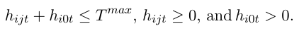

NOTE: contains mathematical notation; text above is the PDF text layer and symbols may be mis-extracted. Image shows the original.

(2)

16

Page 18

In the above, *Uijt* is the utility to play game *j* for *hijt* hours, a function of the consumer’s persistent

preferences and utility shocks. *cthi*0*t* is the consumer’s utility from spending time *hi*0*t* on non-

gaming activities, from which she derives utility of *ct* per hour. The time allocation problem

has three constraints: a time-budget constraint, a non-negativity constraint, and a positive outside

good constraint (one cannot spend all day gaming). The first two constraints are naturally satisfied

given any time allocations. The third constraint holds for more than 99% of all consumer-day level

observations.

Given these constraints, the usage decision in occasion *t* can be decomposed into two sequential

stages: first, the consumer chooses which game to play; second, she decides how much time to

allocate to the chosen game. We parameterize the utility function based on the multiple discrete-

continuous (MDC) utility specifications in Bhat (2018).

*Uijt*(*hijt*) = *γ ·* (Ψ*ijt* + *µijt*) *·* log

**equation / math rendering (image)**

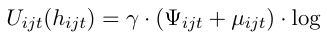

NOTE: contains mathematical notation; text above is the PDF text layer and symbols may be mis-extracted. Image shows the original.

*hijt*

**equation / math rendering (image)**

NOTE: contains mathematical notation; text above is the PDF text layer and symbols may be mis-extracted. Image shows the original.

*γ* + 1

+ *ωijt,* (3)

**equation / math rendering (image)**

NOTE: contains mathematical notation; text above is the PDF text layer and symbols may be mis-extracted. Image shows the original.

where Ψ*ijt* shifts the marginal utility of playing game *j*, and *γ* captures how quickly consumers

are satiated from playing a game. Two separate utility shocks affect consumers at different points

during the decision process: *ωijt* realizes before the consumer picks a game, capturing any factors

influencing which game she chooses, and follows the type-1 extreme value distribution; *µijt* realizes

after the consumer starts playing the game, representing in-game stimuli such as game achievements,

and follows a standard normal distribution.

A consumer’s optimization problem goes as follows. First, the consumer chooses whether to

play a game and, if so, which game to play, solving

max *j∈Lit∪{*0*}*

**equation / math rendering (image)**

NOTE: contains mathematical notation; text above is the PDF text layer and symbols may be mis-extracted. Image shows the original.

E*µijt*

**equation / math rendering (image)**

NOTE: contains mathematical notation; text above is the PDF text layer and symbols may be mis-extracted. Image shows the original.

*γ ·* (Ψ*ijt* + *µijt*) *·* log

**equation / math rendering (image)**

NOTE: contains mathematical notation; text above is the PDF text layer and symbols may be mis-extracted. Image shows the original.

*h∗*

**equation / math rendering (image)**

NOTE: contains mathematical notation; text above is the PDF text layer and symbols may be mis-extracted. Image shows the original.

*ijt γ* + 1

**equation / math rendering (image)**

NOTE: contains mathematical notation; text above is the PDF text layer and symbols may be mis-extracted. Image shows the original.

+ *cth<sup>∗</sup>*

**equation / math rendering (image)**

NOTE: contains mathematical notation; text above is the PDF text layer and symbols may be mis-extracted. Image shows the original.

*i*0*t*

**equation / math rendering (image)**

NOTE: contains mathematical notation; text above is the PDF text layer and symbols may be mis-extracted. Image shows the original.

+ *ωijt*

**equation / math rendering (image)**

NOTE: contains mathematical notation; text above is the PDF text layer and symbols may be mis-extracted. Image shows the original.

*,* (4)

subject to the budget and non-negativity constraints. The consumer expects herself to choose the

optimal time allocation, *h<sup>∗</sup>*, between *j* and the outside activity, given any *µ* values during the

session. Therefore, she makes the decision by taking an expectation over the distribution of *µijt*.

Next, given the choice of *j* and the realized *µijt*, the consumer decides how long to play game *j*.

Substituting in the time-budget constraint,<sup>19</sup> the consumer maximizes the indirect utility function

max

*hijt*

**equation / math rendering (image)**

NOTE: contains mathematical notation; text above is the PDF text layer and symbols may be mis-extracted. Image shows the original.

*γ ·* (Ψ*ijt* + *µijt*) *·* log

**equation / math rendering (image)**

NOTE: contains mathematical notation; text above is the PDF text layer and symbols may be mis-extracted. Image shows the original.

*hijt*

**equation / math rendering (image)**

NOTE: contains mathematical notation; text above is the PDF text layer and symbols may be mis-extracted. Image shows the original.

*γ* + 1

*−cthijt*

**equation / math rendering (image)**

NOTE: contains mathematical notation; text above is the PDF text layer and symbols may be mis-extracted. Image shows the original.

*, s.t. hijt ≥*0 and *hi*0*t >* 0*.* (5)

**equation / math rendering (image)**

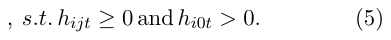

NOTE: contains mathematical notation; text above is the PDF text layer and symbols may be mis-extracted. Image shows the original.

19The constant term *T max* drops out after the substitution.

17

Page 19

The problem has a closed-form solution, *h<sup>∗</sup>*

*ijt* <sup>= max</sup>*<sup>{</sup><sup>γ</sup><sup>·</sup>*<sup>(</sup><sup>Ψ</sup>*<sup>ijt</sup>*<sup>+</sup>*<sup>µ</sup><sup>ijt</sup>*

**equation / math rendering (image)**

NOTE: contains mathematical notation; text above is the PDF text layer and symbols may be mis-extracted. Image shows the original.

*ct −*1)*,* 0*}*.

**equation / math rendering (image)**

NOTE: contains mathematical notation; text above is the PDF text layer and symbols may be mis-extracted. Image shows the original.

**Purchase stage.** Consumer *i* has two purchase occasions at the beginning of each week, and we

denote a week–purchase-occasion combination *tw*. We assume the consumer explicitly accounts for

the changes in game library, and the associated usage decisions and payoffs, in the week following

a purchase decision. That is, whether to purchase a game depends on how the expected maximum

future payoff in the following week changes with the addition of the game. However, to maintain

model tractability, we do not explicitly characterize the consumer’s expectations of one purchase’s

influence on the other purchase occasions or subsequent usages beyond the week. Instead, we cap-

ture these values (and other potential drivers of purchase beyond the week’s usage) with additional

terms in the utility function. Formally, the consumer chooses among the outside goods and the

available games she has not owned (*j ∈{*0*} ∪Jtw\Litw−*1), solving

max *{j∈{*0*}∪Jtw\Litw−*1*}*

**equation / math rendering (image)**

NOTE: contains mathematical notation; text above is the PDF text layer and symbols may be mis-extracted. Image shows the original.

**equation / math rendering (image)**

NOTE: contains mathematical notation; text above is the PDF text layer and symbols may be mis-extracted. Image shows the original.

**equation / math rendering (image)**

NOTE: contains mathematical notation; text above is the PDF text layer and symbols may be mis-extracted. Image shows the original.

E

**equation / math rendering (image)**

NOTE: contains mathematical notation; text above is the PDF text layer and symbols may be mis-extracted. Image shows the original.

*V <sup>usage</sup>*

**equation / math rendering (image)**

NOTE: contains mathematical notation; text above is the PDF text layer and symbols may be mis-extracted. Image shows the original.

*itw* (*Litw−*1 *∪{j}*)

**equation / math rendering (image)**

NOTE: contains mathematical notation; text above is the PDF text layer and symbols may be mis-extracted. Image shows the original.

| {z } expected usage value

+ *V <sup>purch</sup>*

**equation / math rendering (image)**

NOTE: contains mathematical notation; text above is the PDF text layer and symbols may be mis-extracted. Image shows the original.

*ijtw* | {z } purchase value

**equation / math rendering (image)**

NOTE: contains mathematical notation; text above is the PDF text layer and symbols may be mis-extracted. Image shows the original.

*− αij*Price*jtw* | {z } disutil. from expd.

**equation / math rendering (image)**

NOTE: contains mathematical notation; text above is the PDF text layer and symbols may be mis-extracted. Image shows the original.

+ *ϵijtw* |{z} util. shock

**equation / math rendering (image)**

NOTE: contains mathematical notation; text above is the PDF text layer and symbols may be mis-extracted. Image shows the original.

**equation / math rendering (image)**

NOTE: contains mathematical notation; text above is the PDF text layer and symbols may be mis-extracted. Image shows the original.

**equation / math rendering (image)**

NOTE: contains mathematical notation; text above is the PDF text layer and symbols may be mis-extracted. Image shows the original.

*.* (6)

In the above, *V <sup>usage</sup>*

**equation / math rendering (image)**

NOTE: contains mathematical notation; text above is the PDF text layer and symbols may be mis-extracted. Image shows the original.

*itw* denotes the maximum expected utility the consumer derives from playing

games in the following week, given her library *Litw−*1 *∪j*, where the expectation is taken over the

distribution of *ω*. *V <sup>purch</sup>*

**equation / math rendering (image)**

NOTE: contains mathematical notation; text above is the PDF text layer and symbols may be mis-extracted. Image shows the original.

*ijtw* captures utility directly derived from purchasing game *j*, beyond the

utility from playing the game. *αij*Price*jtw* captures the disutility from paying for the purchase, and

*ϵijtw* follows Type I extreme value distribution and captures idiosyncratic factors influencing game

purchase decisions.

**Parameterization.** In Table 4.1, we present how we parameterize consumers’ usage utility Ψ*ijt*,

opportunity cost of time *ct*, purchase utility *V <sup>purch</sup>*

*ijtw* , and price coefficients *αij*.

Table 4.1: Component specifications

| usage | Ψ ijt ct | = ηj + X jλ r(i) = exp( c wkd · weekend t + csmr · summert + chld · holidayt) |
| --- | --- | --- |
| purchase | purch V ijt w αij | = δ j + X jβ r(i) + ξ smr · before sales event t w + ξ hld · sales event t w = α r(i)X j′ |

NOTE: table converted from PDF layout to HTML text; cell boundaries are reconstructed. See PDF if exact alignment matters.

*j* Note: *r*(*i*) indicates the latent type of consumer *i*. *Xj* is the game features (i.e., meta-tags), which we construct as described in Section 3. *ct* is normalized to be 1 for weekdays that are neither during summer times nor holidays.

We include game fixed effects to account for differences in game popularity driven by unique

18

Page 20

content and production quality. To allow for the possibility that consumers perceive the same game

differently at the purchase and usage stages, we introduce two separate sets of fixed effects: *δj* in the

purchase utility function *V <sup>purch</sup>*

*ijtw* , and *ηj* in the usage utility function Ψ*ijt*. We also incorporate time

effects to control for common temporal factors affecting consumer behavior: we allow *ct* to vary

across weekends, summer, and holidays to capture variations in the opportunity cost of playing;

we let *V <sup>purch</sup>*

**equation / math rendering (image)**

NOTE: contains mathematical notation; text above is the PDF text layer and symbols may be mis-extracted. Image shows the original.

*ijtw* differ during sales events and the two weeks leading up to them, capturing changes

in consumers’ propensity to purchase during and before the promotional periods.

We then use a latent-class model to capture unobserved heterogeneity across consumers, al-

lowing arbitrary correlation among the heterogeneous parameters (Kamakura and Russell, 1989).

Specifically, we denote *r* = 1*,* 2*, ..., R* as discrete consumer types in the market and and *ψr* as the

population share of type *r*. We allow for persistent heterogeneity across consumers in their overall

engagement with gaming, preferences for game features, and price sensitivities. In Table 4.1, *Xj*

includes a common intercept and the set of meta-tags representing game features, as constructed in

Section 3. The parameter vectors *λr*(*i*) and *βr*(*i*) capture the preferences of consumer type *r*(*i*) for

gaming in general and for specific game features in the usage and purchase stages, respectively. We

also allow price sensitivities, *αr*(*i*), to vary by consumer type and interact with game features.<sup>20</sup>

**Identification.** Let **Θ**1 = *{**η**, γ, cwkd, csmr, chld,* *δ**, ξsmr, ξhld, σ}* denote the set of homogeneous

**equation / math rendering (image)**

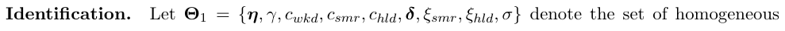

NOTE: contains mathematical notation; text above is the PDF text layer and symbols may be mis-extracted. Image shows the original.

parameters, and let **Θ**2 = *{**β**,* *α**,* *λ**,* *ψ**}* denote the set of heterogeneous parameters. We now

provide an informal discussion on identification.

We identify the usage-stage parameters *{**η**,* *λ**, γ, cwkd, csmr, chld}* from consumers’ choices of

**equation / math rendering (image)**

NOTE: contains mathematical notation; text above is the PDF text layer and symbols may be mis-extracted. Image shows the original.

what to play and how long to play. Specifically, *γ* is identified by the typical duration of game-play

across all titles, while *ηj* and *λ**r* are identified through variation in the frequency and duration of

game-play across games with distinct features. In contrast, we identify purchase-stage parameters

*δj* and *βr*’s from the deviations between consumers’ purchase decisions and their expected usage

values. For example, a consumer who frequently purchases games she rarely plays likely places

high value on certain game features at the time of purchase. Price sensitivities are identified by

consumers’ responses to sharp discounts, which are the predominant source of price variation in the

data. Temporal variation in consumer behavior helps identify the time shifters—weekend, summer,

20Allowing the price sensitivities to vary by game features fits the data considerably better. A plausible explanation is that, due to the recommendation system, consumers may be more frequently exposed to certain games than others. Games not surfaced to a consumer may not enter her consideration set, thereby reducing her responsiveness to discounts on those games. Because our primary focus is not on why consumers react to certain price discounts more than others, and because prices do not enter the recommendation system (Section 3.1), we take the different price responsiveness as given and capture it in a descriptive way.

19

Page 21

and holiday effects for usage, and sales event effects for purchases.

Although we cannot identify the exact number of latent types in the market, we gradually

increase the value of *R* and compare the corresponding model fit. We set *R* = 8 because it provides

a good fit to the observed behavior while keeping the computational burden manageable, as later

discussed in Section 5. Given *R*, we identify latent consumer types leveraging the long panel

structure of our micro data, in which we observe, per consumer, 43 weeks of purchases and 244

days of usage, and up to two purchase or usage occasions per week or day.

**Estimation.** We estimate the demand parameters using maximum likelihood estimation. The

individual likelihood function corresponds to the probability of observing the sequences of pur-

chase and usage decisions, as shown in equation (7). From researchers’ perspective, conditional on

**Θ1**, the randomness in consumer choices arises from two sources: the unobserved consumer type

*θr*(*i*) = *{**β**r,* *α**r,* *λ**r}*, and the unobserved demand shocks *{**ϵ**tw,* *ωt**,* *µt**}*. Therefore, we first derive

**equation / math rendering (image)**

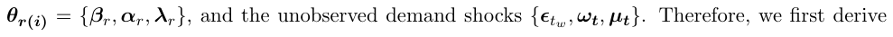

NOTE: contains mathematical notation; text above is the PDF text layer and symbols may be mis-extracted. Image shows the original.

the probability conditional on **Θ***r* = *{***Θ1** *∪**θ**r*(*i*)*}*, and then integrate over the distribution of types.

Because of the independence between *ϵ**tw* and *{**ωt**,* *µt**}*, we can separately compute the likelihood

components for the sequences of purchase and usage decisions. The joint log likelihood, integrated

across consumer types, is:

*LL* =

**equation / math rendering (image)**

NOTE: contains mathematical notation; text above is the PDF text layer and symbols may be mis-extracted. Image shows the original.

X

**equation / math rendering (image)**

NOTE: contains mathematical notation; text above is the PDF text layer and symbols may be mis-extracted. Image shows the original.

*i*

**equation / math rendering (image)**

NOTE: contains mathematical notation; text above is the PDF text layer and symbols may be mis-extracted. Image shows the original.

log(*Li*) =

X

**equation / math rendering (image)**

NOTE: contains mathematical notation; text above is the PDF text layer and symbols may be mis-extracted. Image shows the original.

*i*

**equation / math rendering (image)**

NOTE: contains mathematical notation; text above is the PDF text layer and symbols may be mis-extracted. Image shows the original.

log

**equation / math rendering (image)**

NOTE: contains mathematical notation; text above is the PDF text layer and symbols may be mis-extracted. Image shows the original.

**equation / math rendering (image)**

NOTE: contains mathematical notation; text above is the PDF text layer and symbols may be mis-extracted. Image shows the original.

X

**equation / math rendering (image)**

NOTE: contains mathematical notation; text above is the PDF text layer and symbols may be mis-extracted. Image shows the original.

*r*

**equation / math rendering (image)**

NOTE: contains mathematical notation; text above is the PDF text layer and symbols may be mis-extracted. Image shows the original.

*ψr* |{z} type share

**equation / math rendering (image)**

NOTE: contains mathematical notation; text above is the PDF text layer and symbols may be mis-extracted. Image shows the original.

*·* Y

**equation / math rendering (image)**

NOTE: contains mathematical notation; text above is the PDF text layer and symbols may be mis-extracted. Image shows the original.

*tw*

**equation / math rendering (image)**

NOTE: contains mathematical notation; text above is the PDF text layer and symbols may be mis-extracted. Image shows the original.

Pr(purch*itw|***Θ***r*)

**equation / math rendering (image)**

NOTE: contains mathematical notation; text above is the PDF text layer and symbols may be mis-extracted. Image shows the original.

| {z } prob. purchase sequences

*·* Y

**equation / math rendering (image)**

NOTE: contains mathematical notation; text above is the PDF text layer and symbols may be mis-extracted. Image shows the original.

*t*

**equation / math rendering (image)**

NOTE: contains mathematical notation; text above is the PDF text layer and symbols may be mis-extracted. Image shows the original.

Pr(usage*it|***Θ***r*)

| {z } prob. usage sequences

**equation / math rendering (image)**

NOTE: contains mathematical notation; text above is the PDF text layer and symbols may be mis-extracted. Image shows the original.

**equation / math rendering (image)**

NOTE: contains mathematical notation; text above is the PDF text layer and symbols may be mis-extracted. Image shows the original.

*.* (7)

In the above, type-specific likelihoods for purchase and usage at a given choice occasion are:

Pr(purch*itw|i,* **Θ***r*) = exp( <sup>¯</sup>*Vij,r*) P

**equation / math rendering (image)**

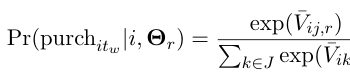

NOTE: contains mathematical notation; text above is the PDF text layer and symbols may be mis-extracted. Image shows the original.

*k∈J* <sup>exp( ¯</sup>*<sup>V</sup><sup>ik,r</sup>*<sup>)</sup>*<sup>,</sup>*

**equation / math rendering (image)**

NOTE: contains mathematical notation; text above is the PDF text layer and symbols may be mis-extracted. Image shows the original.

where <sup>¯</sup>*Vij,r* = E[*V <sup>usage</sup>*

**equation / math rendering (image)**

NOTE: contains mathematical notation; text above is the PDF text layer and symbols may be mis-extracted. Image shows the original.

*itw* (*Litw−*1 *∪j|***Θ***r*)] + *V <sup>purch</sup>*

**equation / math rendering (image)**

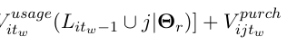

NOTE: contains mathematical notation; text above is the PDF text layer and symbols may be mis-extracted. Image shows the original.

*ijtw −αrj*Price*jtw*

**equation / math rendering (image)**

NOTE: contains mathematical notation; text above is the PDF text layer and symbols may be mis-extracted. Image shows the original.

(8)

and

Pr(usage*it|***Θ***r*) =

**equation / math rendering (image)**

NOTE: contains mathematical notation; text above is the PDF text layer and symbols may be mis-extracted. Image shows the original.

**equation / math rendering (image)**

NOTE: contains mathematical notation; text above is the PDF text layer and symbols may be mis-extracted. Image shows the original.

Pr (0*|i,* **Θ***r*)<sup>start</sup> + <sup>P</sup>

*j∈Lit* <sup>Pr (</sup>*<sup>j</sup><sup>|</sup><sup>i,</sup>***<sup>Θ</sup>***<sup>r</sup>*<sup>)</sup><sup>start</sup>*<sup>·</sup>*<sup>Pr(</sup>*<sup>h</sup><sup>ijt</sup>* <sup>= 0</sup>*<sup>|</sup><sup>i,</sup>***<sup>Θ</sup>***<sup>r</sup>*<sup>)</sup>*<sup>,</sup>* if no positive hours,

**equation / math rendering (image)**

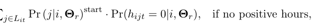

NOTE: contains mathematical notation; text above is the PDF text layer and symbols may be mis-extracted. Image shows the original.

Pr (*j|i,* **Θ***r*)<sup>start</sup> *· f*(*hijt|i,* **Θ***r*)*,* if *hijt >* 0*,*

**equation / math rendering (image)**

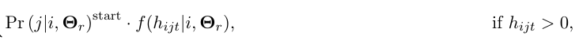

NOTE: contains mathematical notation; text above is the PDF text layer and symbols may be mis-extracted. Image shows the original.

(9)

20

Page 22

For the usage stage, we separate the probability calculation based on whether usage is zero or

positive. Specifically, we account for two sources of zero usage: (i) the consumer chooses not to

start any game, or (ii) the consumer starts a game but allocates zero hours to play after observing

the in-game shock *µ*. Given the optimal hours decision, *h<sup>∗</sup>*= max*{*(<sup>Ψ+</sup>*<sup>µ</sup>*

*c −*1) *· γ,* 0*}*), we map

**equation / math rendering (image)**

NOTE: contains mathematical notation; text above is the PDF text layer and symbols may be mis-extracted. Image shows the original.

observed hour choices back to the distributions of *{**ω**,* *µ**}* and derive the probability of zero usage

in equation (11), along with the conditional density for positive usage, *f*(*hijt | i,* **Θ***r*), in equation

(10).

*f*(*hijt|i,* **Θ***r*) = *f*

**equation / math rendering (image)**

NOTE: contains mathematical notation; text above is the PDF text layer and symbols may be mis-extracted. Image shows the original.

*µijt*(*hijt*)

**equation / math rendering (image)**

NOTE: contains mathematical notation; text above is the PDF text layer and symbols may be mis-extracted. Image shows the original.

*· <sup>∂µ</sup><sup>ijt</sup>*<sup>(</sup>*<sup>h</sup><sup>ijt</sup>*<sup>)</sup> *∂hijt*

**equation / math rendering (image)**

NOTE: contains mathematical notation; text above is the PDF text layer and symbols may be mis-extracted. Image shows the original.

= *ϕ*

**equation / math rendering (image)**

NOTE: contains mathematical notation; text above is the PDF text layer and symbols may be mis-extracted. Image shows the original.

(*<sup>h</sup><sup>ijt</sup>*

**equation / math rendering (image)**

NOTE: contains mathematical notation; text above is the PDF text layer and symbols may be mis-extracted. Image shows the original.

*γ* + 1) *· ct −*Ψ*ijt*

**equation / math rendering (image)**

NOTE: contains mathematical notation; text above is the PDF text layer and symbols may be mis-extracted. Image shows the original.

*· <sup>c</sup><sup>t</sup> γ <sup>,</sup>* (10)

**equation / math rendering (image)**

NOTE: contains mathematical notation; text above is the PDF text layer and symbols may be mis-extracted. Image shows the original.

Pr(*hijt* = 0*|i,* **Θ***r*) = Φ

**equation / math rendering (image)**

NOTE: contains mathematical notation; text above is the PDF text layer and symbols may be mis-extracted. Image shows the original.

*ct −*Ψ*ijt*

**equation / math rendering (image)**

NOTE: contains mathematical notation; text above is the PDF text layer and symbols may be mis-extracted. Image shows the original.

(11)

where *ϕ*(*·*) and Φ(*·*) indicate the probability density function and the cumulative distribution func-

tion of the standard normal distribution. As for the decision to start a game, we map the observed

choices back to the probability space of *ω*, which gives, for *j ∈Lit*:

Pr (*j|i,* **Θ***r*)<sup>start</sup> =

exp

E*µ*

**equation / math rendering (image)**

NOTE: contains mathematical notation; text above is the PDF text layer and symbols may be mis-extracted. Image shows the original.

h

**equation / math rendering (image)**

NOTE: contains mathematical notation; text above is the PDF text layer and symbols may be mis-extracted. Image shows the original.

*Uijt*(*h<sup>∗</sup>*

**equation / math rendering (image)**

NOTE: contains mathematical notation; text above is the PDF text layer and symbols may be mis-extracted. Image shows the original.

*ijt*<sup>)</sup>*<sup>|</sup><sup>j, i</sup>*

**equation / math rendering (image)**

NOTE: contains mathematical notation; text above is the PDF text layer and symbols may be mis-extracted. Image shows the original.

i

**equation / math rendering (image)**

NOTE: contains mathematical notation; text above is the PDF text layer and symbols may be mis-extracted. Image shows the original.

1 + <sup>P</sup> *j<sup>′</sup>∈Lit* <sup>exp</sup>

**equation / math rendering (image)**

NOTE: contains mathematical notation; text above is the PDF text layer and symbols may be mis-extracted. Image shows the original.

E*µ*

**equation / math rendering (image)**

NOTE: contains mathematical notation; text above is the PDF text layer and symbols may be mis-extracted. Image shows the original.

h

**equation / math rendering (image)**

NOTE: contains mathematical notation; text above is the PDF text layer and symbols may be mis-extracted. Image shows the original.

*Uijt*(*h<sup>∗</sup>*

**equation / math rendering (image)**

NOTE: contains mathematical notation; text above is the PDF text layer and symbols may be mis-extracted. Image shows the original.

*ijt*<sup>)</sup>*<sup>|</sup><sup>j</sup><sup>′</sup><sup>, i</sup>*

**equation / math rendering (image)**

NOTE: contains mathematical notation; text above is the PDF text layer and symbols may be mis-extracted. Image shows the original.

i*,* (12)

**equation / math rendering (image)**

NOTE: contains mathematical notation; text above is the PDF text layer and symbols may be mis-extracted. Image shows the original.

and Pr (0*|i,* **Θ***r*)<sup>start</sup> = 1 *−*<sup>P</sup>

*j∈Lit* <sup>Pr (</sup>*<sup>j</sup><sup>|</sup><sup>i,</sup>***<sup>Θ</sup>***<sup>r</sup>*<sup>).</sup> <sup>One</sup> <sup>can</sup> <sup>plug</sup> <sup>(10),</sup> <sup>(11)</sup> <sup>and</sup> <sup>(12)</sup> <sup>back</sup> <sup>into</sup> <sup>(9)</sup> <sup>to</sup>

get Pr(usage*it|***Θ***r*). We use numerical integration to calculate the expectation over *µ*.

Due to computational constraints, we cannot estimate the model on our full dataset. Instead,

we construct a subsample that focuses on popular games during the sample period. Specifically, we

select 171 focal games that constitute a substantial share of revenue or usage time and randomly

sample 6,314 active consumers. The game sample captures the key fraction of the market, with

9 games from Valve, 72 games from 16 large third-party publishers, and 90 games from 88 small

third-party studios. We verify that our feature construction (Section 3) captures the diversified

content of the focal games: on average, each title carries 25 original tags and 4 meta-tags, and

across the 171 games, there are 97 unique meta-tag combinations. See Appendix D.1 for details on

the sampling process.

We aggregate all other games into a “fringe game.” We abstract away from the game features

for the fringe games, normalize their prices to be 0, and introduce (i) a fringe-game fixed effect

and (ii) random coefficients on the fringe game at both the purchase and usage stages. These

21

Page 23

terms allow us to capture heterogeneity in consumers’ tendencies to buy or play fringe games while

preserving model traceability.

**Discussions.** We now discuss the simplifying assumptions we have imposed to maintain model

tractability. First, we assume the consumer has two purchase occasions per week and two usage

occasions per day. The assumption is consistent with the vast majority of consumers’ choices in the

structural sample: 97% of the consumer-week observations have two or fewer game purchases (95%

conditional on at least one purchase), and 97% of the consumer-day observations involve playing

two or fewer games (92% conditional on positive play time).<sup>21</sup>

Second, we assume each purchase decision explicitly accounts for its impact on usage only in

the following week. This assumption rules out dynamic purchase decisions, such as stockpiling,

and thus maintains a tractable, static model. This assumption is plausible given the short gap

between a consumer’s purchase time and her initial playing session: of all observations of consumer

purchase and initial game-play, only 11% start more than seven days after purchase. If stockpiling

were prevalent, one would expect a larger share of purchases to exhibit longer delays before initial

usage. In addition, stockpiling would imply intertemporal substitution around major sales events,

as consumers might delay purchases in anticipation of substantial discounts. However, as shown in

Appendix B, estimated price sensitivities remain similar regardless of whether we control for the

timing of platform-wide sales events. Moreover, post-estimation analysis reveals no evidence of a

dip in the purchase shifter prior to sales events.

Third, we assume consumers’ initial game libraries as exogenously given. One may be concerned

that game libraries are selected based on consumers’ unobserved heterogeneity. However, explicitly

modeling these initial libraries is computationally infeasible.<sup>22</sup> Nevertheless, we show that most

consumers own a small fraction of the focal set of games, so the initial libraries do not vary

significantly across consumers to cause a meaningful selection bias. On average, consumers own 13

of the 171 focal games (median = 10; IQR = 5–18) before the sample starts. In Appendix C.1,

21We do impose that the two purchase occasions are independent, implicitly assuming that when making the first purchase in a week, the consumer does not account for the possibility that she may buy another game in the same week. This simplifying assumption avoids modeling dynamic purchase decisions and makes the model tractable. We note that only in 3% of the weekly observations does the consumer purchase two games, suggesting that this assumption is not crucial. Moreover, these stats hold across the full sample of active Steam users and titles, confirming that the independence assumption is consistent with typical behavior on Steam.

22It is computationally infeasible for two reasons. First, the set of games is large, leading to a large number of possible libraries (as the combination of owned games) and even larger number of possible paths to reach a given library. Second, because libraries evolve non-stationarily, standard approaches for imposing a stationary initialcondition distribution (e.g., Simonov et al. 2020) do not apply.

22

Page 24

we conduct Monte Carlo simulations and show that demand parameters can be recovered when a

similar fraction of games are purchased before the estimation sample begins. As such, we believe

that assuming exogenous libraries does not lead to a significant bias in our demand estimates.

Fourth, we assume the consumer makes informed purchase decisions, abstracting away from

uncertainty about game quality or match values. We consider this assumption plausible, due to

the abundant information available at the time of purchase, including extensive user reviews on

Steam, gameplay videos on YouTube (Li et al., 2025), and live streams from game influencers

(Huang and Morozov, 2025). Furthermore, despite Steam’s generous return policy, only 3.8% of

the initial purchases are returned in our sample. The lack of return suggests that consumers have

limited uncertainty about game quality at the time of purchase, and thus have no regret after

they begin playing the game.<sup>23</sup> Nevertheless, we do allow for discrepancies between purchase- and

usage-stage payoffs, and as we discuss later, these additional terms could capture some extent of

information differences. We also argue that consumers are unlikely to learn about their own match

value to game features over time, because consumers in our sample are experienced gamers. In our

sample, the average consumer has been a player on Steam for 4.3 years (median 3.6 years) prior to

the sample period, and therefore likely know their own preferences over different kinds of games.

Consistent with this conjecture, the distributions of the features among consumers’ first five and

last five purchases are remarkably similar (see Appendix Figure B.3).

Finally, a variety of other factors may also influence consumer demand, including utility directly

from ownership, advertising outside of Steam, personalized recommendations from Steam, learning

of game content post-purchase, and future usage utility beyond the one-week horizon. Abaluck et al.

(2022) argue that if the goal is to characterize equilibrium outcomes under counterfactual scenarios

when demand is held fixed, one can model demand flexibly rather than separating preferences

from alternative demand-driving mechanisms. In our case, we lack data to directly measure these

level) that are not absorbed by expected usage. Accordingly, the results in Section 6 should be

interpreted as the effect of information design conditional on the existing levels of ownership utility,

external advertising, Steam’s recommendation algorithm, post-purchase learning, and any usage

utility beyond one week.

23We infer returns by observations where a game, which was in a user’s library at a certain date, disappears from the library later. In our estimation, we exclude the purchase and usage of the returned games.

23

Page 25

#### **4.2 Supply: information, targeting, and equilibrium pricing**

This section presents the supply model used to simulate equilibrium targeted prices, which in turn

determine key market outcomes such as profits and consumer surplus under alternative designs.

**Information design.** Given that the platform observes the complete purchase and usage histories

of *each* consumer *i*, we assume—and later verify—that it can accurately determine each individual’s

true type, *r*(*i*) *∈{*1*, ..., R}*. The platform then decides what information to disclose to sellers for

targeting individual consumers. Following Section 2, we characterize a platform’s information

design as choosing a *partition* of the set *{*1*, ..., R}*, which we denote as *CR<sup>x</sup>*.

Under full information, the platform discloses the exact type of each consumer, so *CR*<sup>full</sup> =

*{{*1*}, . . . , {R}}*. Under no information, all consumers are pooled together, and *CR*<sup>none</sup> = *{{*1*, . . . , R}}*.

**equation / math rendering (image)**

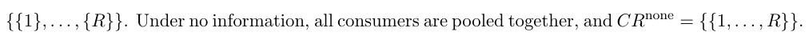

NOTE: contains mathematical notation; text above is the PDF text layer and symbols may be mis-extracted. Image shows the original.

Between these two extremes, the platform may choose to disclose partial information by grouping

types into coarsened segments. For example, grouping types 1 and 2 together and the rest sep-

arately corresponds to *CR<sup>x</sup>* = *{{*1*,* 2*}, {*3*, . . . , R}}*. The platform enforces its chosen information

set across all sellers and overrides any information sellers may otherwise possess about individual

consumers. The enforcement can be implemented through labeling consumers or seller interface

design, as described in Appendix A.1.

**Seller beliefs.** We assume that sellers are fully informed about the overall distribution of con-

sumer types. Given the platform-designed coarsened segments, each seller then forms posterior

beliefs about the type of individual consumers. Recall that *ψr* denotes the ex ante probability that

a randomly selected consumer is of type *r*. Under a coarsened information design, *CR<sup>x</sup>*, the seller

who observes label *cr ∈CR<sup>x</sup>* forms posterior belief

Pr(*r*(*i*) = *r|r*(*i*) *∈cr*) = *ψr* P

**equation / math rendering (image)**

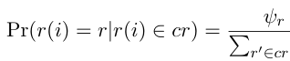

NOTE: contains mathematical notation; text above is the PDF text layer and symbols may be mis-extracted. Image shows the original.

*r<sup>′</sup>∈cr <sup>ψ</sup><sup>r</sup><sup>′</sup><sup>,</sup>* (13)

**equation / math rendering (image)**

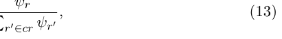

NOTE: contains mathematical notation; text above is the PDF text layer and symbols may be mis-extracted. Image shows the original.

and will set one price for segment *cr ∈CR<sup>x</sup>* given this belief. For example, under *CR<sup>x</sup>* =

*{{*1*,* 2*}, {*3*, ..., R}}*, for each consumer *i* in segment *{*1*,* 2*}*, the seller will expect Pr(*r*(*i*) = 1*|r*(*i*) *∈*

**equation / math rendering (image)**

NOTE: contains mathematical notation; text above is the PDF text layer and symbols may be mis-extracted. Image shows the original.

*{*1*,* 2*}*) = *ψ*1 *ψ*1+*ψ*2 <sup>.</sup> Under no or full information, equation (13) reduces to the prior *ψr* and full

certainty, respectively.<sup>24</sup>

24To elaborate on this point, with *CRnone* = *{{*1*, ..., R}}*, we have Pr(*r*(*i*) = *r|r*(*i*) *∈{*1*, ..., R}*) = Pr(*r*(*i*) = *r*) = *ψr*. Alternatively, with *CR<sup>full</sup>* = *{{*1*}, ..., {R}}*, we have Pr(*r*(*i*) = *r|r*(*i*) *∈cr* where *r ∈cr*) = 1.

**equation / math rendering (image)**

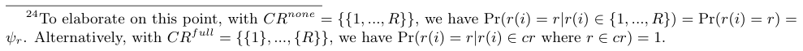

NOTE: contains mathematical notation; text above is the PDF text layer and symbols may be mis-extracted. Image shows the original.

24

Page 26

**Targeted-pricing equilibrium.** Given the platform’s information design, we assume that sellers

play a Nash equilibrium and set one price per coarsened segment. Specifically, for *each* coarsened

segment *cr ∈CR<sup>x</sup>*, seller *f* = 1*, ..., F* solves the optimization problem defined in equation (14),

choosing prices *{pj,cr}j∈Jf* for each of its products to maximize the expected profit from segment

*cr*. For ease of exposition, we omit the time subscript *tw* in the notation.

max *{pj,cr}j∈Jf*

**equation / math rendering (image)**

NOTE: contains mathematical notation; text above is the PDF text layer and symbols may be mis-extracted. Image shows the original.

*J* X

**equation / math rendering (image)**

NOTE: contains mathematical notation; text above is the PDF text layer and symbols may be mis-extracted. Image shows the original.

*j*=1

**equation / math rendering (image)**

NOTE: contains mathematical notation; text above is the PDF text layer and symbols may be mis-extracted. Image shows the original.

*wj,f · pj,cr ·*

**equation / math rendering (image)**

NOTE: contains mathematical notation; text above is the PDF text layer and symbols may be mis-extracted. Image shows the original.

expected purchase probability for coarsened segment *cr* z }| { X

*r∈cr*

**equation / math rendering (image)**

NOTE: contains mathematical notation; text above is the PDF text layer and symbols may be mis-extracted. Image shows the original.

*ψr* P

**equation / math rendering (image)**

NOTE: contains mathematical notation; text above is the PDF text layer and symbols may be mis-extracted. Image shows the original.

*r<sup>′</sup>∈cr <sup>ψ</sup><sup>r</sup><sup>′</sup> <sup>·</sup><sup>s</sup><sup>j,r</sup>*

**equation / math rendering (image)**

NOTE: contains mathematical notation; text above is the PDF text layer and symbols may be mis-extracted. Image shows the original.

*pj,cr,* *p−j,cr*

**equation / math rendering (image)**

NOTE: contains mathematical notation; text above is the PDF text layer and symbols may be mis-extracted. Image shows the original.

*,*

**equation / math rendering (image)**

NOTE: contains mathematical notation; text above is the PDF text layer and symbols may be mis-extracted. Image shows the original.

where ownership weight *wj,f* =

**equation / math rendering (image)**

NOTE: contains mathematical notation; text above is the PDF text layer and symbols may be mis-extracted. Image shows the original.

**equation / math rendering (image)**

NOTE: contains mathematical notation; text above is the PDF text layer and symbols may be mis-extracted. Image shows the original.

0*.*7*, j ∈Jf, f̸* = Valve*,*

**equation / math rendering (image)**

NOTE: contains mathematical notation; text above is the PDF text layer and symbols may be mis-extracted. Image shows the original.

0*, j̸ ∈Jf, f̸* = Valve*,*

**equation / math rendering (image)**

NOTE: contains mathematical notation; text above is the PDF text layer and symbols may be mis-extracted. Image shows the original.

1*, j ∈Jf, f* = Valve*,*

**equation / math rendering (image)**

NOTE: contains mathematical notation; text above is the PDF text layer and symbols may be mis-extracted. Image shows the original.

0*.*3*, j̸ ∈Jf, f* = Valve*.*

**equation / math rendering (image)**

NOTE: contains mathematical notation; text above is the PDF text layer and symbols may be mis-extracted. Image shows the original.

(14)

In the above, *p−j,cr* denotes the prices of all other products in segment *cr*. The share *sj,r*

represents the average purchase probability of game *j* for consumer type *r*, integrated over the

empirical distribution of game libraries *Li* among type *r* consumers—that is, *sj,r* =

R

**equation / math rendering (image)**

NOTE: contains mathematical notation; text above is the PDF text layer and symbols may be mis-extracted. Image shows the original.

Pr(purch*i |*

*Li,* **Θ***r*)*dG*(*Li*). Additionally, we capture the revenue split between Steam and third-party sellers

using *wj,f*. Profits equal revenues in our context due to zero marginal costs.

We emphasize that the standard Bertrand-Nash uniform-pricing equilibrium is a special case of

our broader equilibrium concept, in which sellers rely solely on the prior distribution of consumer

types and set *|J|* uniform prices across all individuals in the market (Berry et al., 1995; Nevo, 2000).

In contrast, under a general information design *CR<sup>x</sup>*, the sellers’ optimization problem gives rise

to *|J| × |CR<sup>x</sup>|* first-order conditions—one for each product-segment combination:

X

**equation / math rendering (image)**

NOTE: contains mathematical notation; text above is the PDF text layer and symbols may be mis-extracted. Image shows the original.

*r∈cr*

**equation / math rendering (image)**

NOTE: contains mathematical notation; text above is the PDF text layer and symbols may be mis-extracted. Image shows the original.

*ψr* P

**equation / math rendering (image)**

NOTE: contains mathematical notation; text above is the PDF text layer and symbols may be mis-extracted. Image shows the original.

*r<sup>′</sup>∈cr <sup>ψ</sup><sup>r</sup><sup>′</sup> <sup>·</sup>*

**equation / math rendering (image)**

NOTE: contains mathematical notation; text above is the PDF text layer and symbols may be mis-extracted. Image shows the original.

*sj,r*

**equation / math rendering (image)**

NOTE: contains mathematical notation; text above is the PDF text layer and symbols may be mis-extracted. Image shows the original.

*pj,cr,* *p−j,cr*

**equation / math rendering (image)**

NOTE: contains mathematical notation; text above is the PDF text layer and symbols may be mis-extracted. Image shows the original.

+ *pj,cr · <sup>∂s</sup><sup>j,r</sup>*

**equation / math rendering (image)**

NOTE: contains mathematical notation; text above is the PDF text layer and symbols may be mis-extracted. Image shows the original.

*pj,cr,* *p−j,cr*

**equation / math rendering (image)**

NOTE: contains mathematical notation; text above is the PDF text layer and symbols may be mis-extracted. Image shows the original.

*∂pj,cr*

**equation / math rendering (image)**

NOTE: contains mathematical notation; text above is the PDF text layer and symbols may be mis-extracted. Image shows the original.

+

X

**equation / math rendering (image)**

NOTE: contains mathematical notation; text above is the PDF text layer and symbols may be mis-extracted. Image shows the original.

*j<sup>′</sup><sup≯</sup>*=*j*

**equation / math rendering (image)**

NOTE: contains mathematical notation; text above is the PDF text layer and symbols may be mis-extracted. Image shows the original.

*wj′,f*

**equation / math rendering (image)**

NOTE: contains mathematical notation; text above is the PDF text layer and symbols may be mis-extracted. Image shows the original.

*wj,f*

**equation / math rendering (image)**

NOTE: contains mathematical notation; text above is the PDF text layer and symbols may be mis-extracted. Image shows the original.

*· pj′,cr · <sup>∂s</sup><sup>j</sup><sup>′</sup><sup>,r</sup>*

**equation / math rendering (image)**

NOTE: contains mathematical notation; text above is the PDF text layer and symbols may be mis-extracted. Image shows the original.

*pj,cr,* *p−j,cr*

**equation / math rendering (image)**

NOTE: contains mathematical notation; text above is the PDF text layer and symbols may be mis-extracted. Image shows the original.

*∂pj,cr* | {z } cannibalization on *j<sup>′</sup>*

**equation / math rendering (image)**

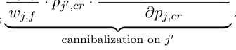

NOTE: contains mathematical notation; text above is the PDF text layer and symbols may be mis-extracted. Image shows the original.

= 0*.*

(15)

Using equation (15), we solve the equilibrium price vector under each possible information

design *CR<sup>x</sup>*, based on the *R* consumer types estimated following Section 4.2.<sup>25</sup> Following Berry

et al. (1995), we assume the existence of a pure strategy equilibrium and verify this assumption

25In all counterfactual simulations, we solve for the equilibrium prices for each week and then average these prices across weeks. We verify that this approach produces similar results to an alternative where we first aggregate demand across weeks and then solve for one static price vector for the entire sample.

25

Page 27

numerically. Our numerical results also indicate that the equilibrium is unique: using 100 different

initial price vectors drawn from a Halton sequence, we find that all starting prices converge to the

same solution.<sup>26</sup>

**Discussions.** We now discuss several assumptions on the supply side model, imposed to maintain

tractability. First, we assume that all sellers know the true distribution of consumer types—that is,

the primitives and the population share of each type—and use this information to calculate expected

profits. This assumption is standard in the literature (e.g., Berry et al., 1995) and is plausible in our

context, given the maturity of the video game market, the availability of accessible industry reports,

and the experience level of participating sellers. Even small studios typically employ professionals

with years of industry experience (Carter, 2024; Clement, 2024; MarketResearch, 2025).

Second, we focus on platform information designs in which information about individual con-

sumers is kept symmetric across sellers. These symmetric designs closely resemble common industry

practices, where platforms provide a standard seller interface featuring a common list of consumer

segments or a standardized set of consumer labels for targeting. We assume that the use of such

common information set is strictly enforced through platform technology, which also serve as a

commitment device: all sellers share the belief that no one can bypass the restrictions to target

individual consumers. Nevertheless, our equilibrium framework can be naturally extended to set-

tings where sellers have and can use different information to infer consumer types, provided there

is common knowledge of all competing sellers’ information sets. We present this more general case

in Appendix D and presents a specific example of extreme asymmetry in information between large

and small sellers in Section 6.

Third, we assume that sellers maximize profits from upfront sales each week, abstracting away

from in-game purchases, in-game advertising, and dynamic pricing. This assumption enables us

to simulate equilibrium outcomes across an exhaustive range of information designs while accom-

modating a reasonably large number of sellers and products, complex market structures, and rich

consumer heterogeneity across multiple dimensions. Other than being necessary, this assumption

is also plausible in our context. As discussed in Section 3, few games on Steam offer in-game

purchases or carry in-game advertising. Furthermore, as discussed in Section 3 and Appendix B,

the extent of price decline over time-since-launch is very small, suggesting a limited extent of price

skimming (Nair, 2007) in this context.

26We conduct this analysis for all focal equilibria discussed in Section 6, including the full-information case, the no-information case, and the optimally coarsened information designs.

26

Page 28

Finally, one might wonder whether consumers would perceive targeted prices as unfair (Kahne-

man et al., 1986) and consequently churn from the market. Although we do not explicitly model

sellers’ decisions regarding regular pricing versus discounts, we envision that platforms implement

targeted pricing through the distribution of personalized coupons or discounts, which potentially

alleviates consumers’ animosity when they are charged a different regular price than the others.

We interpret the segment-specific prices as effective prices net of discounts, following Besanko et al.

(2003); Dub´e et al. (2017); Shiller (2020); Smith et al. (2023). Specifically, a seller could set the

regular price at the highest targeted price level and issue discounts to the remaining consumer

segments. Additionally, although our model does not explicitly incorporate consumer fairness con-

cerns, we address this issue by showing in Section 6 that the optimal coarsened information designs

we propose help alleviate potential fairness concerns by reducing the dispersion in effective prices.

### **5 Estimation results**

We present the composition of consumer types and their heterogeneity based on our estimated

latent class model with *R* = 8. We select *R* = 8 as our final specification because it provides a good

fit to the observed behavior (see Appendix Table C.2) while keeping the computational burden

manageable. Note that the number of information designs, and hence the computation burden in

counterfactual simulations, increases super-exponentially with the number of types. For instance,

increasing the number of types to *R* = 9 would increase the number of possible information designs

from 4*,* 140 to 21*,* 147.<sup>27</sup>

We report the full set of parameter estimates for **Θ1** and **Θ2** in Appendix D. In this section, we

discuss the heterogeneity across consumer types, evaluate our model fit, and examine the model-

implied price elasticities.

**Consumer heterogeneity.** We first summarize the heterogeneity in the overall engagement

across latent consumer types. Figure 5.1 presents, for each consumer type (labeled 1 to 8), the

model-implied average purchase probability across all games in panel (b) and the average price sen-

sitivity in panel (c). We observe substantial heterogeneity reflected in both measures. In particular,

Type 1 consumers (14% of the market) exhibit the highest level of purchase probability, buying

more than one game per month on average. They are also the least price sensitive, with an average

27The number of possible information designs corresponds to the Bell number, which grows super-exponentially with the number of consumer types, as discussed in Appendix A.2.

27

Page 29

price sensitivity of *−*0*.*04. Meanwhile, Types 2 and 8 (collectively 30% of the market) purchase

games far less frequently, averaging one every three months, and display moderate price sensitiv-

ities. In contrast, Types 4 and 7 (16% of the market) are the most price-sensitive types—almost

twice as price sensitive as Type 1 consumers—while purchasing games half as often.

(a) Fraction of Types

Type *r* Fraction ( <sup>ˆ</sup>*ψr*)

Type 1 14% Type 2 11% Type 3 12% Type 4 8% Type 5 22% Type 6 6% Type 7 8% Type 8 19%

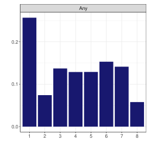

NOTE: figure/graphic rendered as an image from the PDF; its content is not machine-readable text. Caption (if any) follows as the next block.

**text found inside the figure**

Any

1 2 3 4 5 6 7 8

0.0

0.1

0.2

(b) Purchase Probability

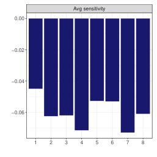

NOTE: figure/graphic rendered as an image from the PDF; its content is not machine-readable text. Caption (if any) follows as the next block.

**text found inside the figure**

Avg sensitivity

1 2 3 4 5 6 7 8

−0.06

−0.04

−0.02

0.00

(c) Price Sensitivity

Figure 5.1: Type distribution, purchase probability, and price sensitivity

Panel (a) shows the fraction of consumers belonging to each type; panel (b) reports the model-implied probability that each type purchases any game; and panel (c) displays the average price sensitivity across all games for each type.

We then explore consumer heterogeneity in tastes for game features. Figure 5.2 presents the

fraction of purchases with the three most popular features—“fantasy,” “multiplayer,” and “mili-

tary.” We find that consumer preferences differ markedly toward game features. Moreover, there is

a correlation between the horizontal and vertical dimensions of consumer heterogeneity—namely,

between feature preferences and overall engagement levels. For example, Type 8 consumers, the

least engaged consumer type, display a clear preference toward games with the “multiplayer” and

“military” feature. Types 1 and 6, both highly engaged, disproportionately favor games with the

“fantasy” feature in purchases. Meanwhile, preferences also diverge across types for other features

such as “team,” “adventure,” “survival,” and “dark,” as suggested by Tables in Appendix D.2.

As discussed in Section 4.1, the model estimates capture not only inherent heterogeneity in

consumer demand but also the influence of demand shifters through other channels. Although our

model remains largely agnostic about the exact mechanism(s) shaping consumer demand, we fur-

ther investigate the relationship between usage-stage and purchase-stage coefficients in Appendix

D. The observed correlation suggests that these parameters likely reflect variation in consumers’

consideration sets. Specifically, consumers are more price sensitive to games with the features

they prefer to purchase and play, indicating that they pay more attention to the prices of games

28

Page 30

with higher match values. This pattern aligns with Steam’s recommendation algorithms, which

tailor game displays based on users’ purchase and usage histories—both reflective of persistent

heterogeneity. In our counterfactual simulations of alternative information designs, we assume con-

sumers’ consideration process is table, which is plausible given that the recommendation algorithm

is independent of market prices.

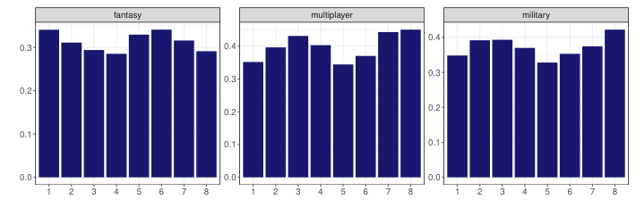

NOTE: figure/graphic rendered as an image from the PDF; its content is not machine-readable text. Caption (if any) follows as the next block.

**text found inside the figure**

fantasy multiplayer military

1 2 3 4 5 6 7 8 1 2 3 4 5 6 7 8 1 2 3 4 5 6 7 8

0.0

0.1

0.2

0.3

0.4

0.0

0.1

0.2

0.3

0.4

0.0

0.1

0.2

0.3

Figure 5.2: Fraction of purchases of games with popular features

Note: The panels report the model-implied probability that each consumer type purchases a game with a given feature, conditional on making a purchase. We present results for the three most popular features among all purchases.

**Model fit.** To examine model fit, we compare model-implied purchase behavior for each consumer

type with the empirical purchase probabilities among consumers of that type. To this end, we

first infer the posterior consumer types given each consumer’s purchase history, using Pr(*r*(*i*) =

*r|purchi, usagei*) = *Li*(*r*)*/* <sup>P</sup>

**equation / math rendering (image)**

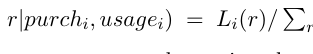

NOTE: contains mathematical notation; text above is the PDF text layer and symbols may be mis-extracted. Image shows the original.

*r<sup>′</sup>*=1*,...,R <sup>L</sup><sup>i</sup>*<sup>(</sup>*<sup>r</sup><sup>′</sup>*<sup>)</sup> <sup>(Kamakura</sup> <sup>and</sup> <sup>Russell,</sup> <sup>1989).</sup> We find that 95%

consumers can be assigned to the most likely type with a posterior probability exceeding 0.9,

suggesting that our long panel data on both purchases and usage can accurately determine consumer

types. This result supports our assumption later that the platform has full information about

consumer types, given that the platform likely has access to even richer data. We then label each

consumer with the most likely type and contrast each type’s empirical purchase behavior with the

model-predicted one. As shown in Figure 5.3, our model closely matches the type-specific purchase

patterns overall and across games with different features.

Further, we also show that the optimal uniform equilibrium prices match with the observed

prices on Steam during our sample period. We compute equilibrium prices using our demand

estimates and assuming all sellers set revenue-maximizing uniform prices according to equation

(15). We demonstrate in Table 5.1 that the model-implied equilibrium prices match well with the

29

Page 31

empirical price distribution. The average equilibrium price is $23, the median is $18, close to the

observed average and median of $26 and $19. Other quantiles of the price distribution are also

similar between model-implied and observed values, and so are the revenue distribution between

large and small sellers and the platform. These results suggest that our demand model and the

equilibrium pricing model provides a good approximation to the observed market outcomes.

Table 5.1: Fit: Observed v.s. Uniform equilibrium

| Equilibrium Outcome | Data | Estimated (Uniform) |
| --- | --- | --- |
| Price ($) : Average | 2566 . | 2326 . |
| Price ($) : 10 percentile | 992 . | 1145 . |
| Price ($) : 25 percentile | 1499 . | 1375 . |
| Price ($) : median | 1916 . | 1768 . |
| Price ($) : 75 percentile | 3461 . | 2674 . |
| Price ($) : 90 percentile | 5227 . | 5099 . |
| Revenue Share Valve - | 347% . | 344% . |
| Revenue Share Large seller - | 4271% . | 3945% . |
| Revenue Share Small seller - | 5382% . | 5711% . |

NOTE: table converted from PDF layout to HTML text; cell boundaries are reconstructed. See PDF if exact alignment matters.

Note: We report the distribution of prices across games in the structural sample, which includes the 171 most popular titles during the sample period. For each game, we calculate the average price across all weeks it appears in the data. Within the structural sample, sellers are classified as large if they offer more than 25 games on Steam, and small if they offer 25 or fewer. We calculate the revenue shares attributed to games published by Valve, third-party large sellers, and third-party small sellers.

**Implied price elasticities and substitution.** How does the estimated heterogeneity translate

into incentives for targeted pricing? Since a game’s optimal price depends directly on its own-

price elasticity—holding the prices of other games constant—we examine how these elasticities

vary across consumer types. Figure 5.4 visually summarizes the price elasticities for each consumer

type for each game, with darker colors representing higher elasticity in magnitude and lighter colors

representing lower elasticities. The average own elasticity across games is *−*1*.*32, and the median is

*−*1*.*12.<sup>28</sup> We observe substantial heterogeneity in elasticities across consumer types, consistent with

variation in their average price sensitivities. Type 1 is the least price elastic type, with an average

elasticity of *−*1*.*02. In contrast, Type 7 is the most price elastic, with an average elasticity of *−*1*.*78.

Importantly, different consumer types also exhibit greater price sensitivity to different games—a

pattern driven by heterogeneity in both tastes for feature and price sensitivities. For example, for

28These estimates indicate slightly lower price elasticity compared to values reported in the previous literature (Haviv et al., 2020), likely because our structural sample focuses on relatively popular games on Steam.

30

Page 32

the most-elastic Type 7, the interquartile range of game-specific elasticities spans from *−*1*.*02 to

*−*2*.*33.

**equation / math rendering (image)**

NOTE: contains mathematical notation; text above is the PDF text layer and symbols may be mis-extracted. Image shows the original.

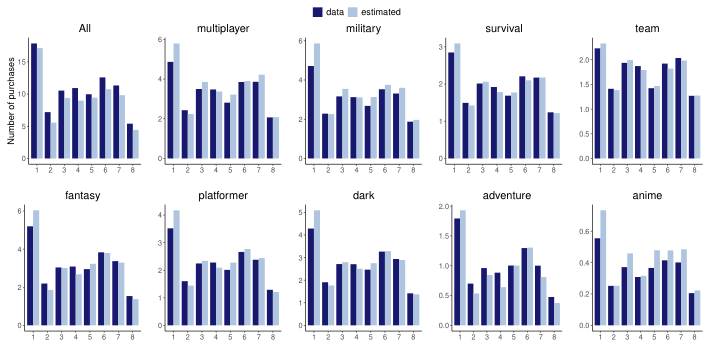

NOTE: figure/graphic rendered as an image from the PDF; its content is not machine-readable text. Caption (if any) follows as the next block.

**text found inside the figure**

data estimated

0

5

10

15

1 2 3 4 5 6 7 8

Number of purchases

All

0

2

4

6

1 2 3 4 5 6 7 8

multiplayer

0

2

4

6

1 2 3 4 5 6 7 8

military

0

1

2

3

1 2 3 4 5 6 7 8

survival

0.0

0.5

1.0

1.5

2.0

1 2 3 4 5 6 7 8

team

0

2

4

6

1 2 3 4 5 6 7 8

fantasy

0

1

2

3

4

1 2 3 4 5 6 7 8

platformer

0

1

2

3

4

5

1 2 3 4 5 6 7 8

dark

0.0

0.5

1.0

1.5

2.0

1 2 3 4 5 6 7 8

adventure

0.0

0.2

0.4

0.6

1 2 3 4 5 6 7 8

anime

Figure 5.3: Consumer heterogeneity: purchases

Note: this figure presents moment fit regarding (1) total number of purchases, (2) number of purchases that involve certain meta-tag. The horizontal axis represents the eight consumer types.

It may appear that the elasticity matrix presented in Figure 5.4 is sufficient to inform the

platform’s information design for targeted pricing. After all, absent seller competition, a game’s

own-price elasticities across consumer types could directly inform how that game should vary prices

by consumer. However, our model estimates imply that, on average, removing a game from the

market results in 18% of its market share being diverted to other games. This diversion ratio varies

significantly across consumer types—ranging from 7% to 28%—with Type 1 consumers exhibiting

the highest diversion, suggesting that competition is intense for this highly engaged consumer

type. When information design segments the market into submarkets (e.g., if it isolates Type 1

into its own submarket), it changes the intensity of competition in each submarket and among

different sellers. Therefore, information design potentially has an important impact on competing

sellers’ pricing strategies. In the next section (Section 6), we demonstrate the importance of these

equilibrium considerations.

31

Page 33

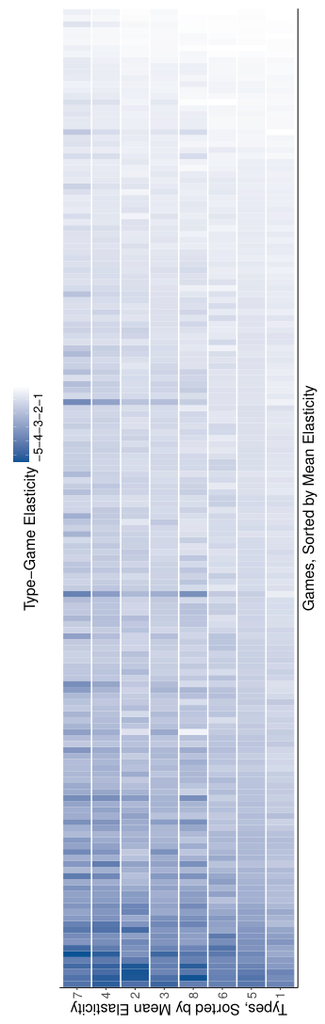

NOTE: figure/graphic rendered as an image from the PDF; its content is not machine-readable text. Caption (if any) follows as the next block.

**text found inside the figure**

1

5

6

8

3

2

4

7

Games, Sorted by Mean Elasticity

Types, Sorted by Mean Elasticity

Type−Game Elasticity

−5−4−3−2−1

Figure 5.4: Own elasticities across games and consumer types.

Note: We evaluate all price elasticities at the observed prices. The darker a tile is, the more price-elastic the type is towards the game. We sort the types by their

mean elasticity (across games) and sort the games by their market-level elasticities.

32

Page 34

### **6 Designing Sellers’ Information for Price Targeting**

Combining the demand estimates from Section 5 with the equilibrium pricing model in Section 4.2,

we exhaustively simulate counterfactual equilibrium outcomes across all possible information de-

signs. We begin by evaluating how information design impacts profits at varying levels of granularity

of segmentation (Section 6.1). We focus on the combined profits of itself and all third-party sellers,

total profits. Next, we demonstrate that segmenting types using demand-based heuristics alone fails

to approximate the profit increases achieved by the optimal, profit-maximizing, information design

(Section 6.2). We then demonstrate the robustness of our key finding—the necessity of accounting

for seller competition—across alternative distributions of consumer heterogeneity (Section 6.3) and

under objectives different from total profits (Section 6.4).

#### **6.1 The profit impact of platform information design**

We begin by evaluating all 4*,* 140 possible information designs, each as a distinct way of partitioning

the eight consumer types into segments. In practice, a platform may prefer a limited number of

coarse segments to reduce implementation or menu costs (Sheshinski and Weiss, 1977), protect

consumer privacy (Goldfarb and Tucker, 2019),<sup>29</sup> or address fairness concerns (Kahneman et al.,

1986) by restricting price dispersion. As such, we focus on comparing information designs with

the same number of segments *n* (denoted as “Coarse *n*”)—different information designs with a

similar level of granularity. Figure 6.1 presents the distribution of the percentage increase in total

market profits achieved by various “Coarse *n*” designs relative to the no-information benchmark

(uniform pricing equilibrium). Note that “Coarse 8” design is equivalent to full information price

targeting, where all sellers can target the true type of each consumer. “Coarse 2” to “Coarse 7”

designs involve the platform grouping some consumers into coarsened segments, allowing sellers to

set targeted prices based on partial consumer information.

We highlight two observations in Figure 6.1. First, price targeting under any information design

yields positive incremental profits relative to uniform pricing. The highest profits arise from full-

information targeting—the most granular design—which increases total seller profits by 2.88%.

29For instance, as described in Appendix A.1, Google’s switching from FLoC to the Topics API reduces the granularity of consumer information by replacing fine-grained behavioral cohorts with broader, rotating interest categories, enhancing privacy while preserving targeting utility.

33

Page 35

The profit increase translates to approximately $123.8 million in additional annual profits based

on Steam’s estimated $4.3 billion total revenue in 2017.<sup>30</sup> This substantial profit increase suggests

that targeted prices’ ability to capture consumer heterogeneity outweighs their impact on price

competition, alleviating concerns about intensified competition when sellers target (see Holmes

1989; Corts 1998; Dub´e et al. 2017, and our conceptual example in Section 2).

Second, whereas targeting under any information design improves profits directionally, the

magnitude of profit increase varies substantially across specific designs, even when the granularity,

*n* is held constant. As illustrated by the box plots in Figure 6.1, the median percentage profit

increase across all possible “Coarse 2” designs is only 0.45%, with the minimum being 0.05%, both

substantially below the 1.74% achieved by the optimal “Coarse 2” design. Likewise, “Coarse 3”

and “Coarse 4” designs’ median profit increases are 0.96% and 1.41%, respectively, with minimum

increases of just 0.17% and 0.39%—much lower than the optimal “Coarse 2” design. These patterns

underscore that platform information design is not merely about the granularity of segmentation.

Rather, *how* to segment given the granularity can substantially affect the incremental profit from

targeting.

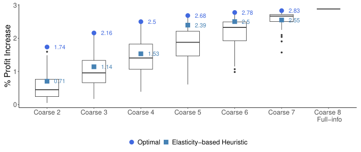

NOTE: figure/graphic rendered as an image from the PDF; its content is not machine-readable text. Caption (if any) follows as the next block.

**text found inside the figure**

1.74

2.16

2.5 2.68 2.78 2.83

0.71

1.14

1.53

2.39 2.5 2.55

0

1

2

3

Coarse 2 Coarse 3 Coarse 4 Coarse 5 Coarse 6 Coarse 7 Coarse 8

Full−info

% Profit Increase

Optimal Elasticity−based Heuristic

Figure 6.1: Profit increases from coarsened information designs

Note: The box plots demonstrate how the profit increases from targeting vary across alternative information designs given the same number of segments, *n*. The lines in the boxes indicate medians, while the bins indicate the interquartile ranges. The blue circle indicates the optimal design achieved by our comprehensive search across all possible designs, whereas the steel blue square indicates the profit level achieved by the elasticity-based heuristic approach.

30Sergey Galyonkin, who runs a third-party monitoring website SteamSpy, estimated Steam’s total sales revenue at $4*.*3 billion for 2017. Source: https://mcvuk.com/business-news/steam-made-4-3b-in-game-sales-in-2017-50 -from-top-100-games.

34

Page 36

#### **6.2 Understanding the importance of equilibrium considerations**

We have shown that, given the number of segments *n*, the optimal (total-profit-maximizing) design,

identified through counterfactual simulations that explicitly account for each information design’s

impact on equilibrium pricing strategies, generates substantially higher profits than most alternative

designs. This finding leads to a natural question: how important is equilibrium consideration in

information design? Can practitioners use demand heuristics to achieve comparable performance?

To answer this question, we use a heuristic approach that clusters consumer types into coarse

segments solely on the similarity of their own-price elasticities across video games. Specifically, for

each *n*, we calculate pairwise Euclidean distances between the type-specific elasticity vectors and

then apply k-means clustering to minimize the within-cluster sum of squared distances. Because

own-price elasticity is closely related to optimal single-product pricing, this procedure ensures that

types that are grouped into the same segment are similar in the demand metric that is relevant to

most games’ pricing.<sup>31</sup> We present the profit increases achieved by this elasticity-based heuristic

using the steelblue squares in Figure 6.1.

We find that elasticity-based heuristic designs consistently underperform the optimal informa-

tion designs for each level of granularity *n*. The profit gap is especially pronounced when *n* is

small—cases in which the platform deliberately limits seller information through coarsened seg-

ments with low granularity. For “Coarse 2” to “Coarse 4” designs, the gap in percentage profit

increase is approximately one percentage point, corresponding to annual profit differences of $42–44

We then present what segments are formed under the elasticity-based heuristic approach and

our optimal information designs in Table 6.1. The differences between the two approaches are

evident. Elasticity-based heuristics tend to isolate consumer type(s) that exhibit distinct elasticity

patterns from the rest of the consumer types. By contrast, the optimal designs sometimes pool

these distinct types with others. For instance, the heuristic “Coarse 2” design separates Type

7—the most price-elastic group for most games—from the other types. In contrast, the optimal

design combines Type 7 with four other types that are closer in the average price elasticity level

but differ in their preferences for specific game features. This result deviates from the intuition

from monopolistic pricing settings, where recent literature emphasizes isolating distinct consumer

31Visually, this clustering approach is akin to finding similarly colored *rows* in Figure 5.4

35

Page 37

types using increasingly rich demand-side variables or advanced models to estimate heterogeneous

preferences or treatment effects precisely (Shiller, 2020; Smith et al., 2023; Zhang and Misra, 2022).

With competing sellers, however, optimal information design for price targeting must account for

the nuanced impact of segmentation on how sellers compete “locally” within each segment, and

hence their competitive pricing strategies.

Table 6.1: Profitability Comparison: Optimal v.s. Heuristic

| Heuristic Segmentation | % Profit gain | Optimal Segmentation | % Profit gain |
| --- | --- | --- | --- |
| {1 2 3 4 5 6 8} {7} , , , , , , , | 0 71 . | {1 5 6} {2 3 4 7 8} , , , , , , , | 1 74 . |
| {1 2 3 5 6 8} {4} {7} , , , , , , , | 1 14 . | {1} {2 5 6 8} {3 4 7} , , , , , , , | 2 16 . |
| {1 2 3 5 6} {4} {7} {8} , , , , , , , | 1 53 . | {1} {2 8} {3 4 7} {5 6} , , , , , , , | 2 50 . |
| {1} {2 3 5 6} {4} {7} {8} , , , , , , , | 2 39 . | {1} {2 8} {3} {5 6} {4 7} , , , , , , , | 2 68 . |
| {1} {2 3 5} {4} {6} {7} {8} , , , , , , , | 2 50 . | {1} {2} {3} {5 6} {4 7} {8} , , , , , , , | 2 78 . |
| {1 5} {2} {3} {4} {6} {7} {8} , , , , , , , | 2 55 . | {1} {2} {3} {4} {5 6} {7} {8} , , , , , , , | 2 83 . |

NOTE: table converted from PDF layout to HTML text; cell boundaries are reconstructed. See PDF if exact alignment matters.

Note: we measure the profitability of a given segmentation by its % incremental profit increases relative to the uniform pricing equilibrium. For readability, in this figure, we suppress the outer braces and braces for singleton sets. For example, we denote information set *{{*1*,* 2*,* 3*,* 4*,* 5*,* 6*,* 8*}, {*7*}}* by *{*1*,* 2*,* 3*,* 4*,* 5*,* 6*,* 8*}, {*7*}*.

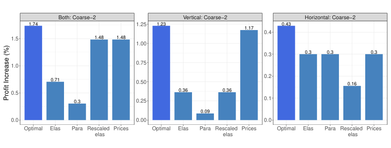

NOTE: figure/graphic rendered as an image from the PDF; its content is not machine-readable text. Caption (if any) follows as the next block.

**text found inside the figure**

1.74

0.3

0.71

1.48 1.48

1.23

0.09

0.36 0.36

1.17 0.43

0.3 0.3

0.16

0.3

Both: Coarse−2 Vertical: Coarse−2 Horizontal: Coarse−2

Optimal Elas Para Rescaled

elas

Prices Optimal Elas Para Rescaled

elas

Prices Optimal Elas Para Rescaled

elas

Prices

0.0

0.1

0.2

0.3

0.4

0.00

0.25

0.50

0.75

1.00

1.25

0.0

0.5

1.0

1.5

Profit Increase (%)

Figure 6.2: Profit gaps: alternative heuristics and alternative demand.

Note: This figure compares the profit increases achieved by various heuristic approach under alternative distributions of consumer heterogeneity with *n* = 2. We use three different heuristics to cluster consumers into coarsened segments: their own-price elasticities across games (“Elas”), the full vector of utility parameters (“Para”), and the rescaled ownprice elasticities relative to each game’s most elastic type (“Rescaled elas”). We also include a heuristic based on full-information equilibrium prices (“Prices”). The left panel shows results under the estimated (factual) demand distribution with both vertical and horizontal heterogeneity; the middle panel uses a counterfactual distribution with isolated vertical heterogeneity; and the right panel uses a distribution with isolated horizontal heterogeneity. In this and subsequent figures, we use blue bars to highlight the “Optimal” design and steel blue bars for all other approaches or cases.

36

Page 38

One might question whether own-price elasticities across games are the most appropriate metric

for capturing demand heterogeneity across consumer types. To address this, we further construct

two alternative demand-based heuristics. First, we cluster consumer types based on their type-

specific demand parameters (*βr*, *αr*, and *γr*). Second, we cluster based on rescaled own-price

elasticities, which adjust for the differences in price elasticities across games.<sup>32</sup> The left panel of

Figure 6.2 shows that neither of the two alternative measures (“para” and “rescaled elas”) aligns

with the optimal information design and, as we demonstrate later, neither consistently approximates

the optimal design across alternative demand structures. These results further underscore that

segmenting consumers based solely on similarities in preferences or price elasticities is insufficient

for effective information design.

One might further conjecture that heuristics incorporating some supply-side factors—such as

the distribution of competing sellers and the positioning of differentiated products in the product

feature space—could help approximate the optimal design without simulating all counterfactual

information designs. A natural heuristic that reflects these considerations is to cluster consumers

based on their type-specific equilibrium prices under full information. These prices capture both

demand heterogeneity and equilibrium pricing incentives under the most granular information de-

sign. However, as shown in the left panel of Figure 6.2, this approach still underperforms the

optimal information design. We conjecture that this gap persists because coarsened information

designs induce equilibrium price responses that are specific to the coarse market partitions they

create. Hence, they cannot be inferred from the equilibrium prices under full information, which

only captures the competition under a specific information design.

#### **6.3 Unpacking consumer heterogeneity**

How do different components of consumer heterogeneity contribute to the profit gap between the

heuristic approach and the optimal information design? Is there a specific dimension of consumer

heterogeneity that drives the previous findings? To answer these questions, we examine counter-

factual equilibrium outcomes under optimal information designs and heuristics-based designs when

consumer heterogeneity is limited to a single dimension.

Guided by two different theoretical frameworks, we decompose consumer heterogeneity into

32Specifically, for each game *j*, we rescale the own-price elasticities by dividing each type’s elasticity by the elasticity of the most price-sensitive type for that game: ˜*ηjj<sup>r</sup>* = *−ηjj<sup>r</sup>/* max*r |η<sup>r</sup>*

*jj<sup>|</sup>*<sup>.</sup> <sup>Visually,</sup> <sup>this</sup> <sup>clustering</sup> <sup>approach</sup> <sup>is</sup> <sup>similar</sup> to finding similarly colored *rows* in Figure D.3. The darker tiles indicate higher relative elasticity—i.e., greater price sensitivity compared to other types—for a given game.

37

Page 39

two dimensions: vertical and horizontal heterogeneity. To isolate the vertical dimension, we retain

only the differences in average engagement and price sensitivity across types while removing all

feature-specific taste shifters. This consumer composition mirrors the set-up in Holmes (1989),

where consumers differ only vertically and all sellers compete for the same “strong” versus “weak”

markets. To isolate the horizontal dimension, we equalize average engagement and price sensitivity

across types but preserve variation in taste for specific game features. This consumer composition

mirrors the set-up in Thisse and Vives (1988) and Corts (1998), where sellers have asymmetric

incentives to target consumer types—that is, one game’s “strong” market may be another game’s

“weak” market. In Appendix Figure D.4, we visualize the elasticity patterns corresponding to the

two counterfactual consumer compositions.

Despite that the eight consumer types differ along both vertical and horizontal dimensions,

we find that vertical heterogeneity is the primary driver of profit increases in Steam’s market.

As shown in Figure 6.3, targeting based on full information about vertical heterogeneity yields a

1.73% increase in total market profits relative to uniform pricing. In contrast, targeting based solely

on horizontal preference heterogeneity leads to a more modest 0.96% increase. Nevertheless, the

positive profit impact under purely horizontal heterogeneity alleviates concerns that asymmetric

rankings of “strong” versus “weak” markets across sellers will lead to profit losses under targeted

pricing (Corts, 1998; Dub´e et al., 2017).

(a) Vertical (full-info profit increase: 1.73%)

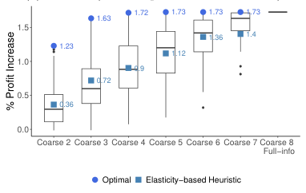

NOTE: figure/graphic rendered as an image from the PDF; its content is not machine-readable text. Caption (if any) follows as the next block.

**text found inside the figure**

1.23

1.63 1.72 1.73 1.73 1.73

0.36

0.72

0.9

1.12

1.36 1.4

0.0

0.5

1.0

1.5

Coarse 2 Coarse 3 Coarse 4 Coarse 5 Coarse 6 Coarse 7 Coarse 8

Full−info

% Profit Increase

Optimal Elasticity−based Heuristic

(b) Horizontal (full-info profit increase: 0.96%)

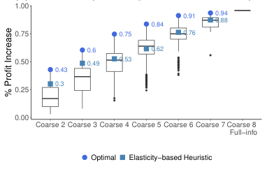

NOTE: figure/graphic rendered as an image from the PDF; its content is not machine-readable text. Caption (if any) follows as the next block.

**text found inside the figure**

0.43

0.6

0.75

0.84 0.91 0.94

0.3

0.49 0.53

0.62

0.76

0.88

0.00

0.25

0.50

0.75

1.00

Coarse 2 Coarse 3 Coarse 4 Coarse 5 Coarse 6 Coarse 7 Coarse 8

Full−info

% Profit Increase

Optimal Elasticity−based Heuristic

Figure 6.3: Unpacking heterogeneity: profit gaps persist

Note: The box plots demonstrate how the profit increases from targeting vary across alternative information designs given the same number of segments, *n*, under the two counterfactual consumer compositions. As in Figure 6.1, the blue circle indicates the optimal design achieved by our comprehensive search across all possible designs, whereas the steel blue square indicates the profit level achieved by the elasticity-based heuristic approach.

More importantly, our key finding—that clustering consumers on similarity in demand alone

38

Page 40

design (0.36% vs. 1.23%). This result suggests that even with simple lower-dimensional hetero-

geneity and associated elasticity patterns, and with directionally aligned seller pricing incentives,

demand-based heuristics still underperforms the optimal design.

We further explore the performance of these heuristics using alternative demand-based metrics

and full-information equilibrium prices in the right two panels of Figure 6.2. Among the three

demand-based heuristics, none consistently approximates the performance of the optimal informa-

tion design. This suggests that the gap is not due to the complexity of demand alone. However,

we do observe that segmentation using full-information equilibrium prices is closer to the optimal

information design, especially when consumer heterogeneity is purely vertical. Taken together,

these findings underscore the critical importance of incorporating supply-side considerations when

designing information for competing sellers, even when consumer heterogeneity is relatively simple

and limited to a single dimension.

#### **6.4 Other platform objectives**

Our earlier analyses in Sections 6.1 through 6.3 have focused on total profits as the primary platform

objective. However, it is important to note that our equilibrium framework can also be used

to evaluate alternative platform objectives that depend on equilibrium prices. In this section,

we examine how well the optimal information design for *n* = 2—selected by maximizing total

platform and seller profits—aligns with other objectives the platform may value. Specifically, we

consider three alternative objectives that reflect long-term platform goals or potential incentive

misalignments: (1) consumer welfare, (2) profit redistribution between large and small sellers, and

(3) the platform’s own profit, which includes 100% of profits from Valve’s own games and 30% of

profits from third-party titles.

**Consumer welfare.** The platform may care about consumer welfare, which could affect user

retention and, in turn, platform growth in the long run. We measure consumer welfare as the

inclusive value of owning video games and compare the changes in welfare under targeting relative

to the uniform pricing equilibrium.<sup>33</sup> Figure 6.4 presents these changes across three information

33We do acknowledge that our consumer welfare calculation assumes the estimated demand parameters reflect true underlying preferences, an assumption not required for evaluating counterfactual prices and profits under different

39

Page 41

designs: the elasticity-based heuristic “Coarse 2” design, the optimal “Coarse 2” design, and the

full information design. We find that full information design increases consumer welfare by 115

utils, representing a 1.72% improvement over the uniform pricing baseline of 6,685 utils. Notably,

the optimal “Coarse 2” design captures most of the welfare increase despite its reduced granularity.

In contrast, the heuristic “Coarse 2” design yields little to no improvement in consumer welfare

relative to the baseline, despite its same level of granularity as the optimal “Coarse 2” design.

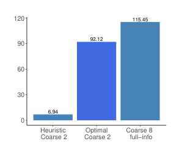

NOTE: figure/graphic rendered as an image from the PDF; its content is not machine-readable text. Caption (if any) follows as the next block.

**text found inside the figure**

6.94

92.12

115.45

0

30

60

90

120

Heuristic Coarse 2

Optimal Coarse 2

Coarse 8

full−info

Figure 6.4: Consumer Welfare Change Relative to the Uniform Pricing Benchmark (in Utils)

What makes the profit-maximizing optimal “Coarse 2” design also effective in improving con-

sumer welfare? In Appendix Table D.7, we further examine how each information design impacts

each consumer type. We find that the optimal “Coarse 2” design significantly lowers the aver-

age price charged to segment *{*2*,* 3*,* 4*,* 7*,* 8*}* (58% of all consumers) while only bringing a modest

price increase for segment *{*1*,* 5*,* 6*}* (42% of all consumers). Specifically, the former group receives

an average price discount of 21.8% relative to the baseline uniform price—approximately $6 per

game—resulting in substantial welfare gains. In contrast, the latter group sees only a 5.5% price

increase—about $0.89 per game—yielding limited welfare loss. In other words, the optimal “Coarse

2” design causes prices to fall sharply for the majority of types, thereby increasing total quantity

and consumer welfare. This finding is in line with Dub´e and Misra (2023)’s results from a monopoly

market. It is worth noting that our measure of consumer welfare does not incorporate intrinsic pref-

erences for privacy (Lin, 2022) or concerns about price fairness. If these factors were accounted

for, the “Coarse 2” design would likely further approximate—or even surpass—the consumer wel-

fare achieved by the full-information design, while maintaining a clear advantage over the heuristic

approach.

information designs.

40

Page 42

**Information symmetry between large versus small sellers.** Recent discussions have raised

concerns that larger sellers—owing to their broader product portfolios and longer operating histories—

may possess an informational advantage over smaller sellers. If exploited, this advantage could

allow large sellers to crowd out smaller competitors, ultimately diminishing product variety on the

platform over time.<sup>34</sup>

In light of this discussion, we examine a concerning asymmetric information structure, where

large sellers (those with more than 25 games) hold and can use full information for targeting, but

the small sellers (25 games or fewer) hold no information and cannot target at all. This represents a

scenario where the platform does not actively design information or imposed common segmentation

for sellers, but instead allows sellers to use their own information about consumers. We compare

this asymmetric targeting case to three key information designs—heuristic “Coarse 2,” optimal

“Coarse 2,” and full information. As we show in Figure 6.5, this asymmetric information scenario

would significantly benefit large sellers at the expense of small sellers. In contrast, the optimal

“Coarse 2” design achieves a more balanced distribution of profit increases across seller sizes, while

also delivering a comparable total profit to the asymmetric case. Therefore, the symmetric, profit-

maximizing “Coarse 2” design also aligns with the platform’s incentive to level the playing field

between large and small sellers.

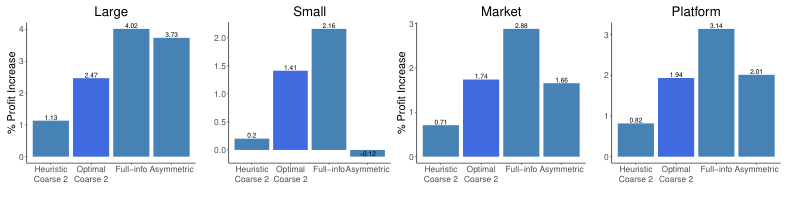

NOTE: figure/graphic rendered as an image from the PDF; its content is not machine-readable text. Caption (if any) follows as the next block.

**text found inside the figure**

4.02 3.73

1.13

2.47

0

1

2

3

4

Heuristic Coarse 2

Optimal Coarse 2

Full−info Asymmetric

% Profit Increase

Large

2.16

−0.12

0.2

1.41

0.0

0.5

1.0

1.5

2.0

Heuristic Coarse 2

Optimal Coarse 2

Full−infoAsymmetric

Small

2.88

1.66

0.71

1.74

0

1

2

3

Heuristic Coarse 2

Optimal Coarse 2

Full−info Asymmetric

% Profit Increase

Market

3.14

2.01

0.82

1.94

0

1

2

3

Heuristic Coarse 2

Optimal Coarse 2

Full−info Asymmetric

Platform

Figure 6.5: Alternative objectives: profit increases for different parties.

Note: This figure presents profit increases under alternative information designs for different stakeholders: third-party large sellers, third-party small sellers, the entire market (platform plus third-party sellers), and the platform itself. We use the uniform-pricing equilibrium as the benchmark.

**Platform self-preferencing.** Further, we examine the impact of different information designs

on platform profits versus third-party seller profits. As we have discussed in Section 3, Valve

34A growing body of literature suggests that the asymmetric effects of policies like Europe’s General Data Protection Regulation (GDPR) could provide large firms with an extra competitive edge over the smaller firms (Campbell et al., 2015; Bourreau et al., 2017; Jia et al., 2018; Bleier et al., 2020; Johnson et al., 2023; Zhao et al., 2021), exacerbating the disparities between large and small sellers.

41

Page 43

serves both as a platform, which collects commission fees from third-party sales, and a seller, which

develops and sells its own games. Recent literature and policy discussions are concerned about

platform designs that serve the platform’s own interest rather than sellers’ interests (Congress, 2021;

European Commission, 2022). We examine whether Valve’s dual role creates incentives to adopt an

information design that maximizes its own profits at the expense of the broader marketplace. We

find that the profit-maximizing information designs for Valve given each *n* are identical to those

reported in Table 6.1, which maximize total profits. Moreover, as shown in Figure 6.5, the relative

profit increases for Valve under the three designs follow a pattern similar to the increase in total

profits. This incentive *alignment* reflects the fact that Valve’s own titles constitute only a small

revenue share of the entire market, as mentioned in Section 3.

### **7 Conclusion**

We empirically study a platform’s problem in designing targetable consumer segments for competing

sellers, which we refer to as “platform information design.” Using novel micro data from Steam,

we estimate a flexible demand model that captures heterogeneous consumer demand and develop

a targeted pricing model to simulate equilibrium outcomes under all counterfactual information

designs with discrete consumer types. Because targetable information partitions the market and

changes how sellers compete with each other, accounting for the equilibrium impact is paramount in

information design. To this point, our results demonstrate that the profit-maximizing information

design—which distinguishes heterogeneous consumer types while accounting for its equilibrium

impact—yields substantially higher profits compared to demand-based heuristics that ignore this

equilibrium impact.

Our findings offer important managerial implications for platforms that provide consumer in-

formation to competing sellers, showing that the design of targetable segments is not merely an

exercise that tries to distinguish heterogeneous consumer types. Instead, the platform must also

account for how its information design affects seller competition in equilibrium, especially when it

intends to provide only a limited number of consumer segments to sellers.

A limitation of our study is that we use counterfactual simulations to evaluate alternative in-

formation designs, assuming that sellers set optimal targeted prices given an information structure.

Our approach is necessary because it is challenging for any platform to experimentally vary its

information design and let sellers adjust to a new equilibrium. Nevertheless, evaluating platform

42

Page 44

information design using field or natural experiments would constitute a welcome topic of future

research.

We also have imposed various assumptions to simplify our demand model—including limited

learning about quality or match value, full consideration sets (even though we approximate limited

consideration with flexible demand parameters), and a lack of forward-looking purchase behavior

beyond a fixed horizon. Whereas we present evidence in support of these assumptions in our setting,

migrating our framework to a different context would require one to re-examine these assumptions.

For example, in an evolving market with less experienced consumers, learning or other forms of

demand dynamics may be prevalent, necessitating a different demand model and potentially altering

sellers’ pricing incentives.

### **References**

Abaluck, J., G. Compiani, and F. Zhang (2022). A method to estimate discrete choice models that

is robust to consumer search. Technical report, Technical report, Working Paper.

Adams, B. and K. R. Williams (2019). Zone pricing in retail oligopoly. *American Economic Journal:*

*Microeconomics 11*(1), 124–56.

Armstrong, M. (2006). Recent developments in the economics of price discrimination.

Bell, E. T. (1934). Exponential numbers. *The American Mathematical Monthly 41*(7), 411–419.

Bergemann, D. and A. Bonatti (2015). Selling cookies. *American Economic Journal: Microeco-*

*nomics 7*(3), 259–294.

Bergemann, D. and A. Bonatti (2024). Data, competition, and digital platforms. *American Eco-*

*nomic Review 114*(8), 2553–2595.

Bergemann, D. and S. Morris (2019). Information design: A unified perspective. *Journal of Economic Literature 57*(1), 44–95.

Berry, S., J. Levinsohn, and A. Pakes (1995). Automobile prices in market equilibrium. *Economet-*

*rica: Journal of the Econometric Society*, 841–890.

Besanko, D., J.-P. Dub´e, and S. Gupta (2003). Competitive price discrimination strategies in a

vertical channel using aggregate retail data. *Management Science 49*(9), 1121–1138.

Bhargava, H. K., O. Rubel, E. J. Altman, R. Arora, J. Boehnke, K. Daniels, T. Derdenger,

B. Kirschner, D. LaFramboise, P. Loupos, et al. (2020). Platform data strategy. *Marketing Letters 31*, 323–334.

Bhat, C. R. (2018). A new flexible multiple discrete–continuous extreme value (mdcev) choice

model. *Transportation Research Part B: Methodological 110*, 261–279.

Bleier, A., A. Goldfarb, and C. Tucker (2020). Consumer privacy and the future of data-based

innovation and marketing. *International Journal of Research in marketing 37*(3), 466–480.

43

Page 45

Bourreau, M., A. De Streel, and I. Graef (2017). Big data and competition policy: Market power,

personalised pricing and advertising. *Personalised Pricing and Advertising (February 16, 2017)*.

Brecko, K. (2023). New features free of charge? intertemporal product versions and pricing in the

software market. *Marketing Science 42*(1), 61–86.

Campbell, J., A. Goldfarb, and C. Tucker (2015). Privacy regulation and market structure. *Journal*

*of Economics & Management Strategy 24*(1), 47–73.

Carter, J. (2024). Veteran devs claim smaller teams could mean more successful games.

Chen, Y. and G. Iyer (2002). Research note consumer addressability and customized pricing. *Marketing Science 21*(2), 197–208.

Clement, J. (2024). Video game industry - statistics & facts.

Congress, U. (2021). American innovation and choice online act. https://www.congress.gov/

bill/117th-congress/senate-bill/2992. Accessed: 2025-05-14.

Corts, K. S. (1998). Third-degree price discrimination in oligopoly: all-out competition and strate-

gic commitment. *The RAND Journal of Economics*, 306–323.

Crawford, G. S. and A. Yurukoglu (2012). The welfare effects of bundling in multichannel television

markets. *American Economic Review 102*(2), 643–85.

Dub´e, J.-P., Z. Fang, N. Fong, and X. Luo (2017). Competitive price targeting with smartphone

coupons. *Marketing Science 36*(6), 944–975.

Dub´e, J.-P. and S. Misra (2023). Personalized pricing and consumer welfare. *Journal of Political*

*Economy 131*(1), 131–189.

European Commission (2022). Regulation (eu) 2022/1925 of the european parliament and of the

council of 14 september 2022 on contestable and fair markets in the digital sector and amending regulations (eu) 2017/2394 and (eu) 2019/1150 (digital markets act). Accessed: 2025-05-14.

Goldfarb, A. and C. Tucker (2019). Digital economics. *Journal of economic literature 57*(1), 3–43.

Haviv, A., Y. Huang, and N. Li (2020). Intertemporal demand spillover effects on video game

platforms. *Management Science 66*(10), 4788–4807.

Holmes, T. J. (1989). The effects of third-degree price discrimination in oligopoly. *The American*

*Economic Review 79*(1), 244–250.

Hopenhayn, H. and M. Saeedi (2022). Optimal simple ratings.

Hopenhayn, H., M. Saeedi, and C. Tepper (2022). Optimal information disclosure and market

outcomes. *Theoretical Economics*.

Huang, Y. and I. Morozov (2025). The promotional effects of live streams by twitch influencers.

*Marketing Science*.

Hui, X., Z. Liu, and W. Zhang (2023). From high bar to uneven bars: The impact of information

granularity in quality certification. *Management Science*.

44

Page 46

Hui, X., M. Saeedi, G. Spagnolo, and S. Tadelis (2021). Raising the bar: Certification thresholds

and market outcomes. *American Economic Journal: Microeconomics*.

Ishihara, M. and A. T. Ching (2019). Dynamic demand for new and used durable goods without

physical depreciation: The case of japanese video games. *Marketing Science 38*(3), 392–416.

Jia, J., G. Z. Jin, and L. Wagman (2018). The short-run effects of gdpr on technology venture

investment. Technical report, National Bureau of Economic Research.

Johnson, G. A., S. K. Shriver, and S. G. Goldberg (2023). Privacy and market concentration:

intended and unintended consequences of the gdpr. *Management Science*.

Kahneman, D., J. L. Knetsch, and R. Thaler (1986). Fairness as a constraint on profit seeking:

Entitlements in the market. *The American economic review*, 728–741.

Kamakura, W. A. and G. J. Russell (1989). A probabilistic choice model for market segmentation

and elasticity structure. *Journal of marketing research 26*(4), 379–390.

Li, N., A. Haviv, and M. J. Lovett (2025). Opposing influences of youtube influencers: Purchase

and usage effects in the video game industry. *Marketing Science*.

Lin, T. (2022). Valuing intrinsic and instrumental preferences for privacy. *Marketing Science 41*(4),

663–681.

MarketResearch (2025). Video games market research reports & video games industry analysis.

Nair, H. (2007). Intertemporal price discrimination with forward-looking consumers: Application

to the us market for console video-games. *Quantitative Marketing and Economics 5*(3), 239–292.

Nevo, A. (2000). Mergers with differentiated products: The case of the ready-to-eat cereal industry.

*The RAND Journal of Economics*, 395–421.

Pancras, J. and K. Sudhir (2007). Optimal marketing strategies for a customer data intermediary.

*Journal of Marketing research 44*(4), 560–578.

Pennington, J., R. Socher, and C. D. Manning (2014). Glove: Global vectors for word representa-

tion. In *Proceedings of the 2014 conference on empirical methods in natural language processing (EMNLP)*, pp. 1532–1543.

Rao, A. (2015). Online content pricing: Purchase and rental markets. *Marketing Science 34*(3),

430–451.

Rossi, P. E., R. McCulloch, and G. Allenby (1996). The value of household information in target

marketing. *Marketing Science 15*(3), 321–340.

Rota, G.-C. (1964). The number of partitions of a set. *The American Mathematical Monthly 71*(5),

498–504.

Shaffer, G. and Z. J. Zhang (1995). Competitive coupon targeting. *Marketing Science 14*(4), 395–416.

Sheshinski, E. and Y. Weiss (1977). Inflation and costs of price adjustment. *The Review of Economic*

*Studies 44*(2), 287–303.

45

Page 47

Shiller, B. R. (2020). Approximating purchase propensities and reservation prices from broad consumer tracking. *International Economic Review 61*(2), 847–870.

Simonov, A., J.-P. Dub´e, G. Hitsch, and P. Rossi (2020). State-dependent demand estimation with

initial conditions correction. *Journal of Marketing Research 57*(5), 789–809.

Smith, A. N., S. Seiler, and I. Aggarwal (2023). Optimal price targeting. *Marketing Science 42*(3),

476–499.

Sunada, T. (2018). Customer learning and revenue-maximizing trial design.

Thisse, J.-F. and X. Vives (1988). On the strategic choice of spatial price policy. *The American*

*Economic Review*, 122–137.

Vatter, B. (2022). Quality disclosure and regulation: Scoring design in medicare advantage. *Avail-*

*able at SSRN 4250361*.

Zhang, W. W. and S. Misra (2022). Coarse personalization. *arXiv preprint arXiv:2204.05793*.

Zhao, Y., P. Yildirim, and P. K. Chintagunta (2021). Privacy regulations and online search friction:

Evidence from gdpr. *Available at SSRN 3903599*.

Zuckerman, A. (2020). 75 steam statistics: 2020/2021 facts, market share & data analysis.

46

Page 48

### **A Platform information provision in practices**

#### **A.1 Segmentation: reveal partial information about consumers for targeting**

(a) Google: topics of interest

[figure not shown]

NOTE: figure/graphic rendered as an image from the PDF; its content is not machine-readable text. Caption (if any) follows as the next block.

(b) Amazon: membership or history

(c) eBay: pre-defined consumer groups

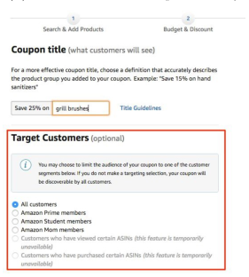

NOTE: figure/graphic rendered as an image from the PDF; its content is not machine-readable text. Caption (if any) follows as the next block.

[figure not shown]

NOTE: figure/graphic rendered as an image from the PDF; its content is not machine-readable text. Caption (if any) follows as the next block.

Figure A.1: Segmentation for Targeting: Google, Amazon, and eBay

Figure A.1 illustrates how platforms enable sellers (or advertisers) to target consumers in groups by

providing predefined labels or segment lists. These examples suggest that information provision through

segmentation is technically feasible through the platform’s design of infrastructure, without transfer of raw

consumer data across business entities.

A central challenge for platforms is striking the right balance between segment granularity and privacy

protection. In 2022, for example, Google replaced its fine-grained Federated Learning of Cohorts (FLoC) ini-

47

Page 49

tiative with the broader Topics API to reduce re-identification risks and enhance user privacy, demonstrating

the importance of using coarser segmentation for effective targeting.

#### **A.2 Number of possible information designs: Derivation**

Let *X* be a finite set consisting of *n* consumer types in the market. A *partition* of *X* can be defined as a

collection of disjoint nonempty type subsets of *X*, whose union is *X*. For example, for *X* = *{a, b, c}*, there

are 5 possible partitions:

*{{a}, {b}, {c}}, {{a, b}, {c}}, {{a, c}, {b}}, {{b, c}, {a}}, {{a, b, c}}.*

**equation / math rendering (image)**

NOTE: contains mathematical notation; text above is the PDF text layer and symbols may be mis-extracted. Image shows the original.

Conceptually, each partition corresponds to a particular information design which constrains how sellers can

target consumer type *a*, *b*, and *c*. Next, we show that the number of possible partitions, and thus information

designs, depends solely on the cardinality of *X*— *n*. We denote this number as *B*(*n*), which is the *n*-th Bell

number (Bell, 1934; Rota, 1964).

**Proof of the recursive formula for** *B*(*n*)**.** Consider a set of *n*+1 elements, and denote the (*n*+1)-th

element *x*. Note that for any partition of the set, element *x* must be in one of the subsets. There are two

possibilities: First, *x* is in a subset by itself. In this case, the remaining *n* elements must be partitioned, and

there are *B*(*n*) ways to do this. In the second case, *x* is in a subset with some other elements. To count the

possible partitions in this case, we can partition the *n* elements into *k* subsets (*k ∈{*1*,* 2*, ...n}*), and add *x*

to one of these *k* subsets. Therefore, we have:

*B*(*n* + 1) = *B*(*n*) +

*n* X

**equation / math rendering (image)**

NOTE: contains mathematical notation; text above is the PDF text layer and symbols may be mis-extracted. Image shows the original.

*k*=1

**equation / math rendering (image)**

NOTE: contains mathematical notation; text above is the PDF text layer and symbols may be mis-extracted. Image shows the original.

*k · S*(*n, k*)*,* (16)

**equation / math rendering (image)**

NOTE: contains mathematical notation; text above is the PDF text layer and symbols may be mis-extracted. Image shows the original.

where *S*(*n, k*) indicate the Stirling numbers of the second kind, which calculates the number of ways to

partition *n* elements into *k* subsets Through algebraic manipulation and the relationship between Stirling

numbers and binomial coefficients, the formula of *B*(*n* + 1) can be transformed into:

*B*(*n* + 1) =

*n* X

**equation / math rendering (image)**

NOTE: contains mathematical notation; text above is the PDF text layer and symbols may be mis-extracted. Image shows the original.

*k*=0

**equation / math rendering (image)**

NOTE: contains mathematical notation; text above is the PDF text layer and symbols may be mis-extracted. Image shows the original.

*n*

**equation / math rendering (image)**

NOTE: contains mathematical notation; text above is the PDF text layer and symbols may be mis-extracted. Image shows the original.

*k*

**equation / math rendering (image)**

NOTE: contains mathematical notation; text above is the PDF text layer and symbols may be mis-extracted. Image shows the original.

*B*(*k*)*,* where *B*(0) = 1*.* (17)

48

Page 50

**Growth Rate of Bell Numbers.** It is noteworthy that *B*(*n*) grow faster than exponentially as *n*

increases. To illustrate, we have the following Bell numbers following the recurrence formula:

*B*(4) = 15

*B*(5) = 52

*B*(6) = 203

*B*(7) = 877

*B*(8) = 4140

*B*(9) = 21147

*B*(10) = 115975 (18)

The growth rate highlights the high-dimensional nature of the information design problem and the rising

computational cost as the number of consumer types increases.

### **B Additional industry details and descriptive patterns**

#### **B.1 Competition outside Steam: negligible**

One may wonder whether Steam competes against other major platforms. To check the relative size of

Steam to its competitors, we collect search data from Google Trends to compare the number of search

queries for Steam and its major competitors, Origin (developed by Electronic Arts), Epic Store (developed

by Epic Games), and Uplay (developed by Ubisoft). As shown in Figure B.1, the search volume for all three

competitor platforms are negligible compared to that for Steam, confirming Steam’s near-monopoly position

in the PC-gaming market.

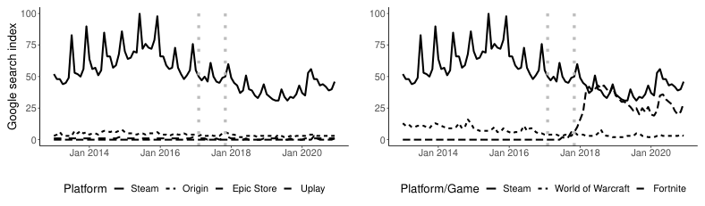

NOTE: figure/graphic rendered as an image from the PDF; its content is not machine-readable text. Caption (if any) follows as the next block.

**text found inside the figure**

0

25

50

75

100

Jan 2014 Jan 2016 Jan 2018 Jan 2020

Google search index

Platform Steam Origin Epic Store Uplay

0

25

50

75

100

Jan 2014 Jan 2016 Jan 2018 Jan 2020

Platform/Game Steam World of Warcraft Fortnite

Figure B.1: Steam takes a near-monopoly position for PC-based gaming.

Note: In both figures, the gray dotted lines denote the start and end of our sample period. The vertical axis measures the Google search index, normalized by the highest value among the platforms (or games) in comparison.

49

Page 51

We also compare the search for Steam against two major PC games outside of any platform. The first one

is *World of Warcraft*, released by Blizzard Entertainment in 2004, and the second one is *Fortnite*, released

by Epic Games in 2017. Both games had low search volumes during our sample period, as the craze for

*World of Warcraft* had already faded, while the spike of interest in *Fortnite* had not arrived. Hence, we do

not consider them as major substitutes for games inside Steam.

#### **B.2 Tags and meta-tags**

We present an example of user-generated tags in Figure B.2 and the defined Meta-tags in Table B.1.

[figure not shown]

NOTE: figure/graphic rendered as an image from the PDF; its content is not machine-readable text. Caption (if any) follows as the next block.

[figure not shown]

NOTE: figure/graphic rendered as an image from the PDF; its content is not machine-readable text. Caption (if any) follows as the next block.

Figure B.2: Example of user-generated tags

Table B.1: Meta-tags Defined

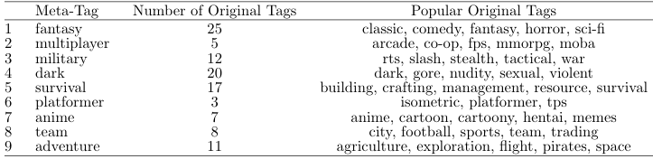

NOTE: complex table shown as an image of the PDF; the text below is a rough machine extraction and may be mis-aligned.

**extracted text (unreliable layout)**

Note: For each meta-tag, we present the top five most frequently used original tags.

#### **B.3 Consumer Learning: negligible**

One might wonder whether consumer learning plays a significant role in the video game market, especially

given the nature of content goods. If consumers engage in learning— either about product quality or how

well different content features match their preferences— our static demand model could misrepresent the

true distribution of consumer heterogeneity. As discussed in Section 4.1, we argue that learning is minimal

50

Page 52

in the Steam market due to the abundance of information available about game quality and the maturity

of most Steam users. We further validate this claim by examining consumers’ return behavior and their

evolving preferences for content features over time below.

Steam offers a generous return policy, allowing consumers to return a game within two weeks of purchase

(or within two days during game-specific free weekends). As we exclude all returned games from our purchase

panel, we find regular returns account for only 3.8% of initial purchases, suggesting that consumers face

limited uncertainty about game quality. We then analyze whether consumers change their preferences for

game features over time. Specifically, for each consumer, we compare the features of their first five purchases

across consumers, indicating minimal shifts in preferences and suggesting that consumer demand remains

stable during our sample period.

dark adventure anime

team fantasy platformer

multiplayer military survival

0.00 0.25 0.50 0.75 1.00 0.00 0.25 0.50 0.75 1.00 0.00 0.25 0.50 0.75 1.00

0.00 0.25 0.50 0.75 1.00 0.00 0.25 0.50 0.75 1.00 0.00 0.25 0.50 0.75 1.00

0.00 0.25 0.50 0.75 1.00 0.00 0.25 0.50 0.75 1.00 0.00 0.25 0.50 0.75 1.00 0

2500

5000

7500

0 2000 4000 6000 8000

0

5000

10000

15000

0

2000

4000

6000

8000

0

2000

4000

6000

0

5000

10000

15000

0

2000

4000

6000

0

2500

5000

7500

10000

0

2000

4000

6000

8000

Fraction of purchases with the feature

Number of consumers

Purchases First 5 Last 5